# Week 3 Case Study: CNN Image Classification with Transfer Learning

**Student Name:** Siddhartha Mukherjee

**Course:** Applied Research Topics in Deep Learning

**Date:** 2026-04-20

## Section 0: Environment Setup

In this section, we:

1. Import all libraries needed for the project (TensorFlow, NumPy, Matplotlib, etc.)
2. Set random seeds so results can be repeated
3. Check that GPU is available (needed for faster training)

```python
# Install libraries (uncomment if running for first time in Colab)
# !pip install -q tensorflow numpy pandas matplotlib seaborn scikit-learn opencv-python

# Import libraries
import os
import random
import time
import numpy as np
import pandas as pd
import matplotlib.pyplot as plt
import seaborn as sns
import cv2

import tensorflow as tf
from tensorflow import keras
from tensorflow.keras import layers
from tensorflow.keras.datasets import cifar10
from sklearn.model_selection import train_test_split
from sklearn.metrics import confusion_matrix, classification_report

# Set random seed for reproducibility
SEED = 42
os.environ['PYTHONHASHSEED'] = str(SEED)
random.seed(SEED)
np.random.seed(SEED)
tf.random.set_seed(SEED)

# Nicer plots
plt.style.use('seaborn-v0_8-whitegrid')

print("TensorFlow version:", tf.__version__)
print("Keras version:", keras.__version__)
print("Setup complete!")
```

```
TensorFlow version: 2.19.0
Keras version: 3.13.2
Setup complete!
```

```python
# Check if GPU is available
gpus = tf.config.list_physical_devices('GPU')
print("Number of GPUs available:", len(gpus))

if len(gpus) > 0:
    print("GPU details:", gpus)
    # Enable memory growth so GPU doesn't grab all memory at once
    for gpu in gpus:
        tf.config.experimental.set_memory_growth(gpu, True)
    print("✅ GPU is ready to use!")
else:
    print("⚠️ No GPU found. Go to Runtime > Change runtime type > T4 GPU")
```

```
Number of GPUs available: 1
GPU details: [PhysicalDevice(name='/physical_device:GPU:0', device_type='GPU')]
✅ GPU is ready to use!
```

# Part 1: Data Exploration & Preprocessing (8 points)

In this section, we will:

1. Load the CIFAR-10 dataset and check its shape
2. Split data into train, validation, and test sets (with class balance)
3. Visualize sample images from each class
4. Analyze class distribution to check balance
5. Study pixel intensity and apply normalization
6. Build a data augmentation pipeline (flips, rotations, zoom, contrast)
7. Create an efficient `tf.data` pipeline with batching and prefetching

```python
# Load CIFAR-10 dataset
(X_train_full, y_train_full), (X_test, y_test) = cifar10.load_data()

# Remove extra dimension from labels
y_train_full = y_train_full.squeeze()
y_test = y_test.squeeze()

# CIFAR-10 class names in order (0 to 9)
class_names = ['airplane', 'automobile', 'bird', 'cat', 'deer',
               'dog', 'frog', 'horse', 'ship', 'truck']

# Print shapes
print("Full training images shape:", X_train_full.shape)
print("Full training labels shape:", y_train_full.shape)
print("Test images shape:", X_test.shape)
print("Test labels shape:", y_test.shape)

# Print pixel statistics
print("\nPixel value statistics (before normalization):")
print(f"  Min: {X_train_full.min()}")
print(f"  Max: {X_train_full.max()}")
print(f"  Mean: {X_train_full.mean():.2f}")
print(f"  Std: {X_train_full.std():.2f}")

print("\nNumber of classes:", len(class_names))
print("Classes:", class_names)
```

```
Downloading data from https://www.cs.toronto.edu/~kriz/cifar-10-python.tar.gz
170498071/170498071 ━━━━━━━━━━━━━━━━━━━━ 4s 0us/step
Full training images shape: (50000, 32, 32, 3)
Full training labels shape: (50000,)
Test images shape: (10000, 32, 32, 3)
Test labels shape: (10000,)

Pixel value statistics (before normalization):
  Min: 0
  Max: 255
  Mean: 120.71
  Std: 64.15

Number of classes: 10
Classes: ['airplane', 'automobile', 'bird', 'cat', 'deer', 'dog', 'frog', 'horse', 'ship', 'truck']
```

```python
# Split full training data into train (90%) and validation (10%)
# stratify=y_train_full keeps class balance in both sets
X_train, X_val, y_train, y_val = train_test_split(
    X_train_full, y_train_full,
    test_size=0.1,
    stratify=y_train_full,
    random_state=SEED
)

print("Training set shape:  ", X_train.shape, "Labels:", y_train.shape)
print("Validation set shape:", X_val.shape, "Labels:", y_val.shape)
print("Test set shape:      ", X_test.shape, "Labels:", y_test.shape)

print(f"\nTotal: {len(X_train) + len(X_val) + len(X_test)} images")
```

```
Training set shape:   (45000, 32, 32, 3) Labels: (45000,)
Validation set shape: (5000, 32, 32, 3) Labels: (5000,)
Test set shape:       (10000, 32, 32, 3) Labels: (10000,)

Total: 60000 images
```

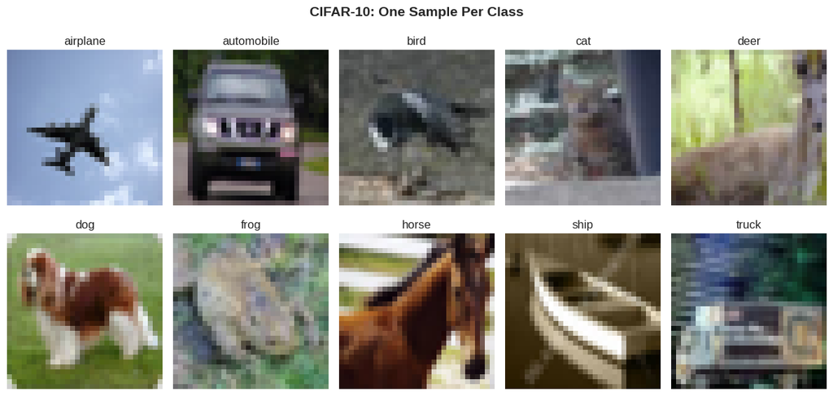

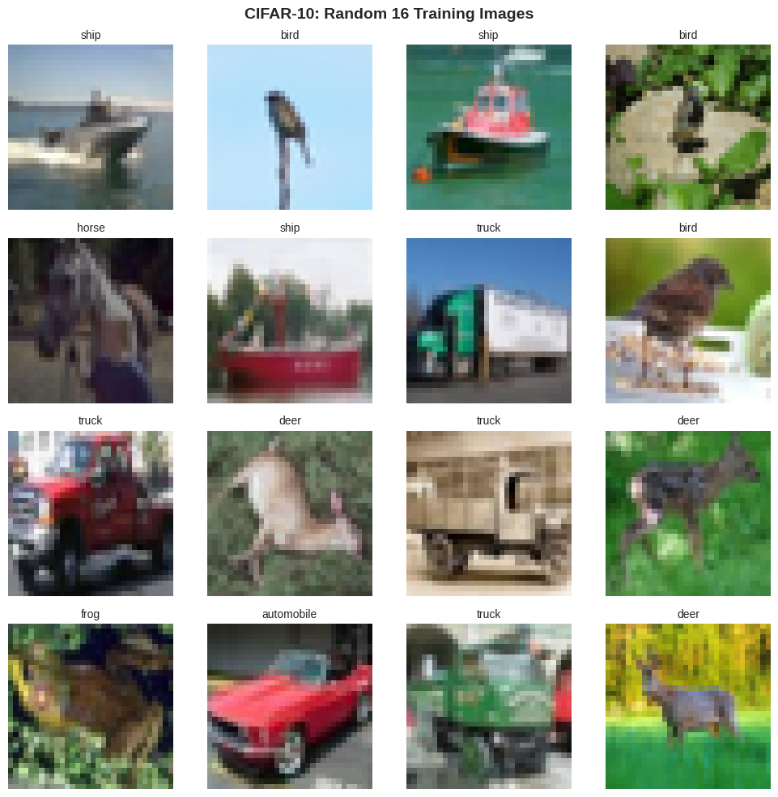

```python
# Show one sample image from each class (4x4 grid, but we only need 10)
plt.figure(figsize=(12, 6))

for class_idx in range(10):
    # Find first image of this class
    idx = np.where(y_train == class_idx)[0][0]
    plt.subplot(2, 5, class_idx + 1)
    plt.imshow(X_train[idx])
    plt.title(f"{class_names[class_idx]}", fontsize=12)
    plt.axis('off')

plt.suptitle("CIFAR-10: One Sample Per Class", fontsize=14, fontweight='bold')
plt.tight_layout()
plt.show()

# Also show a 4x4 random grid of images
plt.figure(figsize=(10, 10))
random_indices = np.random.choice(len(X_train), 16, replace=False)

for i, idx in enumerate(random_indices):
    plt.subplot(4, 4, i + 1)
    plt.imshow(X_train[idx])
    plt.title(class_names[y_train[idx]], fontsize=10)
    plt.axis('off')

plt.suptitle("CIFAR-10: Random 16 Training Images", fontsize=14, fontweight='bold')
plt.tight_layout()
plt.show()
```

```
Class distribution across splits:
        Class  Train  Validation  Test
0    airplane   4500         500  1000
1  automobile   4500         500  1000
2        bird   4500         500  1000
3         cat   4500         500  1000
4        deer   4500         500  1000
5         dog   4500         500  1000
6        frog   4500         500  1000
7       horse   4500         500  1000
8        ship   4500         500  1000
9       truck   4500         500  1000
```

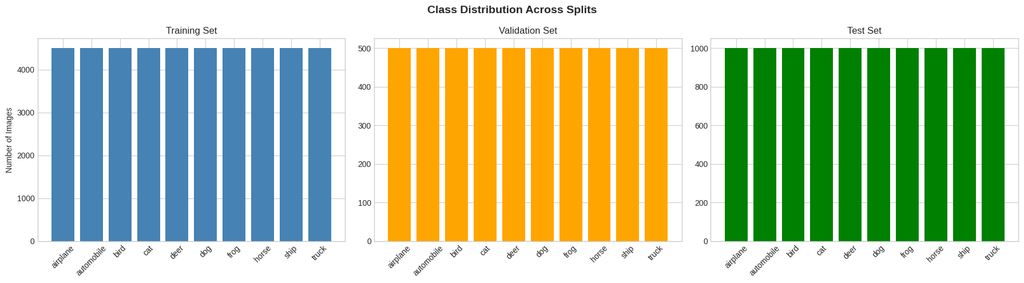

```
✅ Dataset is well-balanced across all classes.
```

```python
# Count number of images per class in each split
def count_classes(labels):
    unique, counts = np.unique(labels, return_counts=True)
    return dict(zip(unique, counts))

train_counts = count_classes(y_train)
val_counts = count_classes(y_val)
test_counts = count_classes(y_test)

# Create a DataFrame for easier plotting
df = pd.DataFrame({
    'Class': class_names,
    'Train': [train_counts[i] for i in range(10)],
    'Validation': [val_counts[i] for i in range(10)],
    'Test': [test_counts[i] for i in range(10)]
})

print("Class distribution across splits:")
print(df)

# Plot bar chart
fig, axes = plt.subplots(1, 3, figsize=(18, 5))

axes[0].bar(class_names, df['Train'], color='steelblue')
axes[0].set_title('Training Set')
axes[0].set_ylabel('Number of Images')
axes[0].tick_params(axis='x', rotation=45)

axes[1].bar(class_names, df['Validation'], color='orange')
axes[1].set_title('Validation Set')
axes[1].tick_params(axis='x', rotation=45)

axes[2].bar(class_names, df['Test'], color='green')
axes[2].set_title('Test Set')
axes[2].tick_params(axis='x', rotation=45)

plt.suptitle('Class Distribution Across Splits', fontsize=14, fontweight='bold')
plt.tight_layout()
plt.show()

print("\n✅ Dataset is well-balanced across all classes.")
```

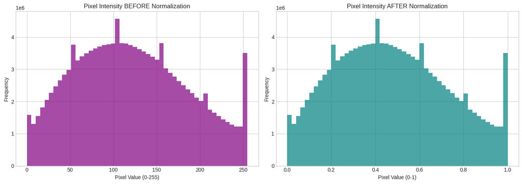

```
Before normalization:
  Range: [0, 255], Mean: 120.67

After normalization (/255):
  Range: [0.00, 1.00], Mean: 0.4732

Per-channel means (after normalization):
  Red:   0.4911
  Green: 0.4821
  Blue:  0.4464
```

```python
# Plot histogram of pixel intensities BEFORE normalization
fig, axes = plt.subplots(1, 2, figsize=(14, 5))

axes[0].hist(X_train.flatten(), bins=50, color='purple', alpha=0.7)
axes[0].set_title('Pixel Intensity BEFORE Normalization')
axes[0].set_xlabel('Pixel Value (0-255)')
axes[0].set_ylabel('Frequency')

# Normalize: convert to float32 and divide by 255
X_train_norm = X_train.astype('float32') / 255.0
X_val_norm = X_val.astype('float32') / 255.0
X_test_norm = X_test.astype('float32') / 255.0

axes[1].hist(X_train_norm.flatten(), bins=50, color='teal', alpha=0.7)
axes[1].set_title('Pixel Intensity AFTER Normalization')
axes[1].set_xlabel('Pixel Value (0-1)')
axes[1].set_ylabel('Frequency')

plt.tight_layout()
plt.show()

# Print statistics
print("Before normalization:")
print(f"  Range: [{X_train.min()}, {X_train.max()}], Mean: {X_train.mean():.2f}")
print("\nAfter normalization (/255):")
print(f"  Range: [{X_train_norm.min():.2f}, {X_train_norm.max():.2f}], Mean: {X_train_norm.mean():.4f}")

# Also analyze per-channel (R, G, B)
print("\nPer-channel means (after normalization):")
print(f"  Red:   {X_train_norm[..., 0].mean():.4f}")
print(f"  Green: {X_train_norm[..., 1].mean():.4f}")
print(f"  Blue:  {X_train_norm[..., 2].mean():.4f}")
```

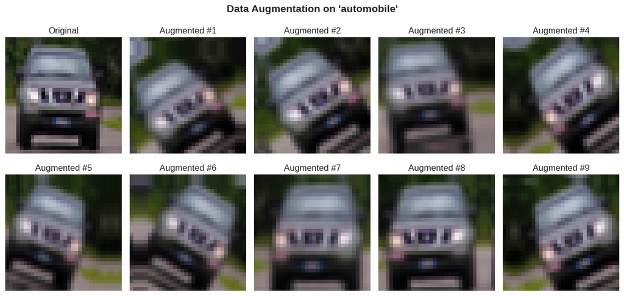

```
✅ Augmentation pipeline ready with: flip, rotation, zoom, contrast, translation
```

```python
# Build data augmentation pipeline
data_augmentation = keras.Sequential([
    layers.RandomFlip("horizontal"),           # flip left-right
    layers.RandomRotation(0.1),                # rotate up to 10%
    layers.RandomZoom(0.1),                    # zoom in/out 10%
    layers.RandomContrast(0.1),                # change contrast
    layers.RandomTranslation(0.1, 0.1),        # shift up/down/left/right
], name="data_augmentation")

# Visualize augmentation on one sample image
sample_image = X_train_norm[0]  # take first image
sample_image_batch = np.expand_dims(sample_image, axis=0)  # add batch dim

plt.figure(figsize=(12, 6))
plt.subplot(2, 5, 1)
plt.imshow(sample_image)
plt.title("Original")
plt.axis('off')

# Show 9 augmented versions
for i in range(9):
    augmented = data_augmentation(sample_image_batch, training=True)
    plt.subplot(2, 5, i + 2)
    plt.imshow(augmented[0].numpy())
    plt.title(f"Augmented #{i+1}")
    plt.axis('off')

plt.suptitle(f"Data Augmentation on '{class_names[y_train[0]]}'", fontsize=14, fontweight='bold')
plt.tight_layout()
plt.show()

print("✅ Augmentation pipeline ready with: flip, rotation, zoom, contrast, translation")
```

```python
# Build efficient tf.data pipelines
BATCH_SIZE = 64
AUTOTUNE = tf.data.AUTOTUNE

# Training dataset: shuffle + augment + batch + prefetch
train_ds = tf.data.Dataset.from_tensor_slices((X_train_norm, y_train))
train_ds = train_ds.shuffle(buffer_size=1000, seed=SEED)
train_ds = train_ds.batch(BATCH_SIZE)
train_ds = train_ds.map(lambda x, y: (data_augmentation(x, training=True), y),
                        num_parallel_calls=AUTOTUNE)
train_ds = train_ds.prefetch(AUTOTUNE)

# Validation dataset: just batch + prefetch (no augmentation)
val_ds = tf.data.Dataset.from_tensor_slices((X_val_norm, y_val))
val_ds = val_ds.batch(BATCH_SIZE).prefetch(AUTOTUNE)

# Test dataset: same as validation
test_ds = tf.data.Dataset.from_tensor_slices((X_test_norm, y_test))
test_ds = test_ds.batch(BATCH_SIZE).prefetch(AUTOTUNE)

print("✅ Data pipelines ready:")
print(f"  Train batches:      {len(list(train_ds))}")
print(f"  Validation batches: {len(list(val_ds))}")
print(f"  Test batches:       {len(list(test_ds))}")
print(f"  Batch size:         {BATCH_SIZE}")

# Verify one batch shape
for batch_images, batch_labels in train_ds.take(1):
    print(f"\nBatch image shape: {batch_images.shape}")
    print(f"Batch label shape: {batch_labels.shape}")
```

```
✅ Data pipelines ready:
  Train batches:      704
  Validation batches: 79
  Test batches:       157
  Batch size:         64

Batch image shape: (64, 32, 32, 3)
Batch label shape: (64,)
```

### Part 1 Summary

**What we did:**

- Loaded CIFAR-10: 45,000 training + 5,000 validation + 10,000 test images
- Data is perfectly balanced across all 10 classes (4,500 images per class in train)
- Normalized pixel values from [0, 255] to [0, 1] for stable training
- Built a rich augmentation pipeline: horizontal flip, rotation, zoom, contrast, translation
- Created efficient `tf.data` pipelines with batching, shuffling, and prefetching

**Why these choices:**

- **Stratified split** keeps class balance in validation set (important for fair evaluation)
- **Normalization to [0,1]** helps gradient descent converge faster
- **Augmentation** adds ~5× more visual variety without needing more data, reducing overfitting
- **Prefetch + parallel calls** keep the GPU busy (no waiting for CPU to prepare data)

# Part 2: Custom CNN Architecture Design (12 points)

In this section, we will design and train **3 custom CNN models** with increasing complexity:

1. **Model A — Baseline CNN**: simple convolutional blocks with pooling
2. **Model B — Improved CNN**: adds Batch Normalization and Dropout for regularization
3. **Model C — Residual CNN**: uses skip connections (ResNet-style blocks)

After training, we will compare:

- Training accuracy vs validation accuracy
- Test accuracy
- Number of parameters
- Training time

```python
# Helper function to plot training history
def plot_history(history, title="Training History"):
    fig, axes = plt.subplots(1, 2, figsize=(14, 5))

    # Accuracy plot
    axes[0].plot(history.history['accuracy'], label='Train', linewidth=2)
    axes[0].plot(history.history['val_accuracy'], label='Validation', linewidth=2)
    axes[0].set_title(f'{title} - Accuracy')
    axes[0].set_xlabel('Epoch')
    axes[0].set_ylabel('Accuracy')
    axes[0].legend()
    axes[0].grid(True)

    # Loss plot
    axes[1].plot(history.history['loss'], label='Train', linewidth=2)
    axes[1].plot(history.history['val_loss'], label='Validation', linewidth=2)
    axes[1].set_title(f'{title} - Loss')
    axes[1].set_xlabel('Epoch')
    axes[1].set_ylabel('Loss')
    axes[1].legend()
    axes[1].grid(True)

    plt.tight_layout()
    plt.show()


# Helper function to train a model and track time
def train_model(model, train_ds, val_ds, epochs=15, model_name="model"):
    print(f"\n{'='*60}")
    print(f"Training: {model_name}")
    print(f"{'='*60}")

    # Early stopping: stop if val_loss doesn't improve for 5 epochs
    early_stop = keras.callbacks.EarlyStopping(
        monitor='val_loss',
        patience=5,
        restore_best_weights=True,
        verbose=1
    )

    start_time = time.time()
    history = model.fit(
        train_ds,
        validation_data=val_ds,
        epochs=epochs,
        callbacks=[early_stop],
        verbose=1
    )
    train_time = time.time() - start_time

    print(f"\n⏱️ Training time: {train_time:.1f} seconds")
    return history, train_time


# Helper function to evaluate on test set
def evaluate_model(model, test_ds, model_name="model"):
    test_loss, test_acc = model.evaluate(test_ds, verbose=0)
    print(f"✅ {model_name} Test Accuracy: {test_acc*100:.2f}% | Test Loss: {test_loss:.4f}")
    return test_acc, test_loss
```

## Model A: Baseline CNN

A simple CNN with 3 convolutional blocks. Each block: `Conv2D → MaxPooling2D`. No Batch Normalization, no Dropout. This is our starting point to beat.

```
Model: "baseline_cnn"
```

```
┏━━━━━━━━━━━━━━━━━━━━━━━━━━━━━━━━━┳━━━━━━━━━━━━━━━━━━━━━━━━┳━━━━━━━━━━━━━━━┓
┃ Layer (type)                    ┃ Output Shape           ┃       Param # ┃
┡━━━━━━━━━━━━━━━━━━━━━━━━━━━━━━━━━╇━━━━━━━━━━━━━━━━━━━━━━━━╇━━━━━━━━━━━━━━━┩
│ input_layer_1 (InputLayer)      │ (None, 32, 32, 3)      │             0 │
├─────────────────────────────────┼────────────────────────┼───────────────┤
│ conv2d (Conv2D)                 │ (None, 32, 32, 32)     │           896 │
├─────────────────────────────────┼────────────────────────┼───────────────┤
│ max_pooling2d (MaxPooling2D)    │ (None, 16, 16, 32)     │             0 │
├─────────────────────────────────┼────────────────────────┼───────────────┤
│ conv2d_1 (Conv2D)               │ (None, 16, 16, 64)     │        18,496 │
├─────────────────────────────────┼────────────────────────┼───────────────┤
│ max_pooling2d_1 (MaxPooling2D)  │ (None, 8, 8, 64)       │             0 │
├─────────────────────────────────┼────────────────────────┼───────────────┤
│ conv2d_2 (Conv2D)               │ (None, 8, 8, 128)      │        73,856 │
├─────────────────────────────────┼────────────────────────┼───────────────┤
│ max_pooling2d_2 (MaxPooling2D)  │ (None, 4, 4, 128)      │             0 │
├─────────────────────────────────┼────────────────────────┼───────────────┤
│ flatten (Flatten)               │ (None, 2048)           │             0 │
├─────────────────────────────────┼────────────────────────┼───────────────┤
│ dense (Dense)                   │ (None, 128)            │       262,272 │
├─────────────────────────────────┼────────────────────────┼───────────────┤
│ dense_1 (Dense)                 │ (None, 10)             │         1,290 │
└─────────────────────────────────┴────────────────────────┴───────────────┘
```

```
 Total params: 356,810 (1.36 MB)
```

```
 Trainable params: 356,810 (1.36 MB)
```

```
 Non-trainable params: 0 (0.00 B)
```

```
============================================================
Training: Model A - Baseline CNN
============================================================
704/704 ━━━━━━━━━━━━━━━━━━━━ 22s 25ms/step - accuracy: 0.3819 - loss: 1.6953 - val_accuracy: 0.4374 - val_loss: 1.5717
704/704 ━━━━━━━━━━━━━━━━━━━━ 14s 20ms/step - accuracy: 0.5034 - loss: 1.3881 - val_accuracy: 0.5468 - val_loss: 1.2758
704/704 ━━━━━━━━━━━━━━━━━━━━ 14s 20ms/step - accuracy: 0.5520 - loss: 1.2587 - val_accuracy: 0.5998 - val_loss: 1.1382
704/704 ━━━━━━━━━━━━━━━━━━━━ 14s 20ms/step - accuracy: 0.5850 - loss: 1.1719 - val_accuracy: 0.5992 - val_loss: 1.1707
704/704 ━━━━━━━━━━━━━━━━━━━━ 21s 21ms/step - accuracy: 0.6092 - loss: 1.1109 - val_accuracy: 0.6164 - val_loss: 1.1223
704/704 ━━━━━━━━━━━━━━━━━━━━ 20s 20ms/step - accuracy: 0.6221 - loss: 1.0677 - val_accuracy: 0.6520 - val_loss: 0.9976
704/704 ━━━━━━━━━━━━━━━━━━━━ 14s 20ms/step - accuracy: 0.6386 - loss: 1.0302 - val_accuracy: 0.6400 - val_loss: 1.0435
704/704 ━━━━━━━━━━━━━━━━━━━━ 15s 21ms/step - accuracy: 0.6491 - loss: 0.9918 - val_accuracy: 0.6496 - val_loss: 0.9871
704/704 ━━━━━━━━━━━━━━━━━━━━ 20s 20ms/step - accuracy: 0.6561 - loss: 0.9721 - val_accuracy: 0.6732 - val_loss: 0.9579
704/704 ━━━━━━━━━━━━━━━━━━━━ 14s 20ms/step - accuracy: 0.6654 - loss: 0.9520 - val_accuracy: 0.6792 - val_loss: 0.9024
704/704 ━━━━━━━━━━━━━━━━━━━━ 14s 20ms/step - accuracy: 0.6730 - loss: 0.9275 - val_accuracy: 0.6922 - val_loss: 0.9260
704/704 ━━━━━━━━━━━━━━━━━━━━ 20s 20ms/step - accuracy: 0.6825 - loss: 0.9039 - val_accuracy: 0.7012 - val_loss: 0.8782
704/704 ━━━━━━━━━━━━━━━━━━━━ 14s 20ms/step - accuracy: 0.6858 - loss: 0.8943 - val_accuracy: 0.6978 - val_loss: 0.8770
704/704 ━━━━━━━━━━━━━━━━━━━━ 21s 20ms/step - accuracy: 0.6929 - loss: 0.8770 - val_accuracy: 0.7222 - val_loss: 0.8106
704/704 ━━━━━━━━━━━━━━━━━━━━ 21s 21ms/step - accuracy: 0.6941 - loss: 0.8619 - val_accuracy: 0.6912 - val_loss: 0.8933
Restoring model weights from the end of the best epoch: 14.

⏱️ Training time: 264.7 seconds
```

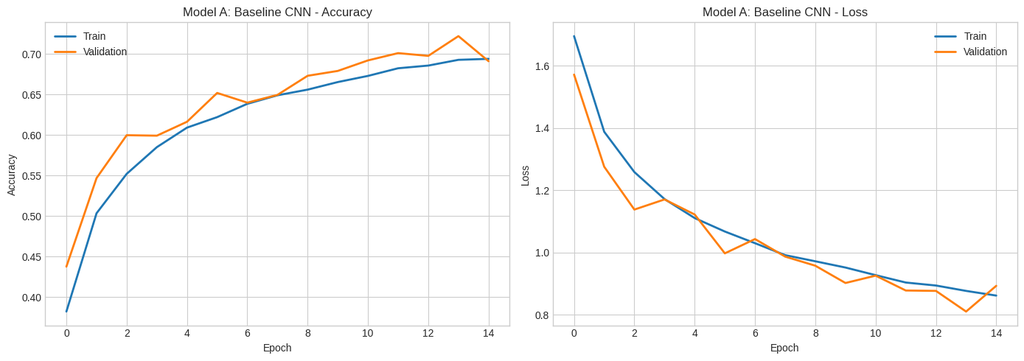

```
✅ Model A - Baseline CNN Test Accuracy: 71.24% | Test Loss: 0.8324
```

```python
def build_baseline_cnn(input_shape=(32, 32, 3), num_classes=10):
    inputs = keras.Input(shape=input_shape)

    # Block 1
    x = layers.Conv2D(32, (3, 3), activation='relu', padding='same')(inputs)
    x = layers.MaxPooling2D((2, 2))(x)

    # Block 2
    x = layers.Conv2D(64, (3, 3), activation='relu', padding='same')(x)
    x = layers.MaxPooling2D((2, 2))(x)

    # Block 3
    x = layers.Conv2D(128, (3, 3), activation='relu', padding='same')(x)
    x = layers.MaxPooling2D((2, 2))(x)

    # Classifier head
    x = layers.Flatten()(x)
    x = layers.Dense(128, activation='relu')(x)
    outputs = layers.Dense(num_classes, activation='softmax')(x)

    return keras.Model(inputs, outputs, name="baseline_cnn")


# Build, compile, and train
model_a = build_baseline_cnn()
model_a.compile(
    optimizer=keras.optimizers.Adam(learning_rate=1e-3),
    loss='sparse_categorical_crossentropy',
    metrics=['accuracy']
)
model_a.summary()

history_a, time_a = train_model(model_a, train_ds, val_ds, epochs=15,
                                model_name="Model A - Baseline CNN")
plot_history(history_a, "Model A: Baseline CNN")
test_acc_a, test_loss_a = evaluate_model(model_a, test_ds, "Model A - Baseline CNN")
```

## Model B: Improved CNN with BatchNorm + Dropout

Same structure as Model A, but we add:

- **Batch Normalization** after each Conv layer → faster, more stable training
- **Dropout** in the classifier → reduces overfitting
- **Two Conv layers per block** → deeper feature extraction

```
Model: "improved_cnn"
```

```
┏━━━━━━━━━━━━━━━━━━━━━━━━━━━━━━━━━┳━━━━━━━━━━━━━━━━━━━━━━━━┳━━━━━━━━━━━━━━━┓
┃ Layer (type)                    ┃ Output Shape           ┃       Param # ┃
┡━━━━━━━━━━━━━━━━━━━━━━━━━━━━━━━━━╇━━━━━━━━━━━━━━━━━━━━━━━━╇━━━━━━━━━━━━━━━┩
│ input_layer_2 (InputLayer)      │ (None, 32, 32, 3)      │             0 │
├─────────────────────────────────┼────────────────────────┼───────────────┤
│ conv2d_3 (Conv2D)               │ (None, 32, 32, 32)     │           896 │
├─────────────────────────────────┼────────────────────────┼───────────────┤
│ batch_normalization             │ (None, 32, 32, 32)     │           128 │
│ (BatchNormalization)            │                        │               │
├─────────────────────────────────┼────────────────────────┼───────────────┤
│ re_lu (ReLU)                    │ (None, 32, 32, 32)     │             0 │
├─────────────────────────────────┼────────────────────────┼───────────────┤
│ conv2d_4 (Conv2D)               │ (None, 32, 32, 32)     │         9,248 │
├─────────────────────────────────┼────────────────────────┼───────────────┤
│ batch_normalization_1           │ (None, 32, 32, 32)     │           128 │
│ (BatchNormalization)            │                        │               │
├─────────────────────────────────┼────────────────────────┼───────────────┤
│ re_lu_1 (ReLU)                  │ (None, 32, 32, 32)     │             0 │
├─────────────────────────────────┼────────────────────────┼───────────────┤
│ max_pooling2d_3 (MaxPooling2D)  │ (None, 16, 16, 32)     │             0 │
├─────────────────────────────────┼────────────────────────┼───────────────┤
│ dropout (Dropout)               │ (None, 16, 16, 32)     │             0 │
├─────────────────────────────────┼────────────────────────┼───────────────┤
│ conv2d_5 (Conv2D)               │ (None, 16, 16, 64)     │        18,496 │
├─────────────────────────────────┼────────────────────────┼───────────────┤
│ batch_normalization_2           │ (None, 16, 16, 64)     │           256 │
│ (BatchNormalization)            │                        │               │
├─────────────────────────────────┼────────────────────────┼───────────────┤
│ re_lu_2 (ReLU)                  │ (None, 16, 16, 64)     │             0 │
├─────────────────────────────────┼────────────────────────┼───────────────┤
│ conv2d_6 (Conv2D)               │ (None, 16, 16, 64)     │        36,928 │
├─────────────────────────────────┼────────────────────────┼───────────────┤
│ batch_normalization_3           │ (None, 16, 16, 64)     │           256 │
│ (BatchNormalization)            │                        │               │
├─────────────────────────────────┼────────────────────────┼───────────────┤
│ re_lu_3 (ReLU)                  │ (None, 16, 16, 64)     │             0 │
├─────────────────────────────────┼────────────────────────┼───────────────┤
│ max_pooling2d_4 (MaxPooling2D)  │ (None, 8, 8, 64)       │             0 │
├─────────────────────────────────┼────────────────────────┼───────────────┤
│ dropout_1 (Dropout)             │ (None, 8, 8, 64)       │             0 │
```

[output cut: 15 more lines]

```
│ max_pooling2d_5 (MaxPooling2D)  │ (None, 4, 4, 128)      │             0 │
├─────────────────────────────────┼────────────────────────┼───────────────┤
│ dropout_2 (Dropout)             │ (None, 4, 4, 128)      │             0 │
├─────────────────────────────────┼────────────────────────┼───────────────┤
│ flatten_1 (Flatten)             │ (None, 2048)           │             0 │
├─────────────────────────────────┼────────────────────────┼───────────────┤
│ dense_2 (Dense)                 │ (None, 256)            │       524,544 │
├─────────────────────────────────┼────────────────────────┼───────────────┤
│ batch_normalization_6           │ (None, 256)            │         1,024 │
│ (BatchNormalization)            │                        │               │
├─────────────────────────────────┼────────────────────────┼───────────────┤
│ dropout_3 (Dropout)             │ (None, 256)            │             0 │
├─────────────────────────────────┼────────────────────────┼───────────────┤
│ dense_3 (Dense)                 │ (None, 10)             │         2,570 │
└─────────────────────────────────┴────────────────────────┴───────────────┘
```

```
 Total params: 816,938 (3.12 MB)
```

```
 Trainable params: 815,530 (3.11 MB)
```

```
 Non-trainable params: 1,408 (5.50 KB)
```

```
============================================================
Training: Model B - Improved CNN
============================================================
704/704 ━━━━━━━━━━━━━━━━━━━━ 36s 34ms/step - accuracy: 0.3429 - loss: 1.8956 - val_accuracy: 0.3802 - val_loss: 1.9759
704/704 ━━━━━━━━━━━━━━━━━━━━ 16s 23ms/step - accuracy: 0.4666 - loss: 1.4728 - val_accuracy: 0.5208 - val_loss: 1.3660
704/704 ━━━━━━━━━━━━━━━━━━━━ 16s 23ms/step - accuracy: 0.5260 - loss: 1.3186 - val_accuracy: 0.5410 - val_loss: 1.3857
704/704 ━━━━━━━━━━━━━━━━━━━━ 16s 22ms/step - accuracy: 0.5663 - loss: 1.2100 - val_accuracy: 0.5600 - val_loss: 1.3368
704/704 ━━━━━━━━━━━━━━━━━━━━ 16s 22ms/step - accuracy: 0.5935 - loss: 1.1407 - val_accuracy: 0.5608 - val_loss: 1.3476
704/704 ━━━━━━━━━━━━━━━━━━━━ 16s 23ms/step - accuracy: 0.6205 - loss: 1.0869 - val_accuracy: 0.6390 - val_loss: 1.0534
704/704 ━━━━━━━━━━━━━━━━━━━━ 16s 22ms/step - accuracy: 0.6327 - loss: 1.0430 - val_accuracy: 0.6596 - val_loss: 0.9419
704/704 ━━━━━━━━━━━━━━━━━━━━ 16s 22ms/step - accuracy: 0.6505 - loss: 0.9988 - val_accuracy: 0.6078 - val_loss: 1.2362
704/704 ━━━━━━━━━━━━━━━━━━━━ 16s 22ms/step - accuracy: 0.6624 - loss: 0.9691 - val_accuracy: 0.5856 - val_loss: 1.3432
704/704 ━━━━━━━━━━━━━━━━━━━━ 17s 24ms/step - accuracy: 0.6734 - loss: 0.9361 - val_accuracy: 0.6918 - val_loss: 0.8731
704/704 ━━━━━━━━━━━━━━━━━━━━ 19s 22ms/step - accuracy: 0.6852 - loss: 0.9115 - val_accuracy: 0.6388 - val_loss: 1.1077
704/704 ━━━━━━━━━━━━━━━━━━━━ 16s 23ms/step - accuracy: 0.6929 - loss: 0.8918 - val_accuracy: 0.6666 - val_loss: 0.9859
704/704 ━━━━━━━━━━━━━━━━━━━━ 16s 23ms/step - accuracy: 0.6978 - loss: 0.8693 - val_accuracy: 0.7168 - val_loss: 0.8476
704/704 ━━━━━━━━━━━━━━━━━━━━ 16s 22ms/step - accuracy: 0.7065 - loss: 0.8485 - val_accuracy: 0.7312 - val_loss: 0.7760
704/704 ━━━━━━━━━━━━━━━━━━━━ 22s 24ms/step - accuracy: 0.7131 - loss: 0.8340 - val_accuracy: 0.6802 - val_loss: 0.9800
704/704 ━━━━━━━━━━━━━━━━━━━━ 16s 22ms/step - accuracy: 0.7166 - loss: 0.8207 - val_accuracy: 0.7406 - val_loss: 0.7385
704/704 ━━━━━━━━━━━━━━━━━━━━ 15s 22ms/step - accuracy: 0.7216 - loss: 0.8024 - val_accuracy: 0.7068 - val_loss: 0.8992
704/704 ━━━━━━━━━━━━━━━━━━━━ 16s 23ms/step - accuracy: 0.7274 - loss: 0.7875 - val_accuracy: 0.7500 - val_loss: 0.7331
704/704 ━━━━━━━━━━━━━━━━━━━━ 16s 22ms/step - accuracy: 0.7304 - loss: 0.7800 - val_accuracy: 0.7010 - val_loss: 0.8443
704/704 ━━━━━━━━━━━━━━━━━━━━ 16s 22ms/step - accuracy: 0.7330 - loss: 0.7713 - val_accuracy: 0.7412 - val_loss: 0.7597
704/704 ━━━━━━━━━━━━━━━━━━━━ 21s 23ms/step - accuracy: 0.7379 - loss: 0.7586 - val_accuracy: 0.7722 - val_loss: 0.6648
704/704 ━━━━━━━━━━━━━━━━━━━━ 16s 22ms/step - accuracy: 0.7435 - loss: 0.7449 - val_accuracy: 0.7456 - val_loss: 0.7560
704/704 ━━━━━━━━━━━━━━━━━━━━ 16s 22ms/step - accuracy: 0.7444 - loss: 0.7452 - val_accuracy: 0.7522 - val_loss: 0.7230
704/704 ━━━━━━━━━━━━━━━━━━━━ 16s 23ms/step - accuracy: 0.7513 - loss: 0.7268 - val_accuracy: 0.7576 - val_loss: 0.7171
704/704 ━━━━━━━━━━━━━━━━━━━━ 20s 23ms/step - accuracy: 0.7560 - loss: 0.7144 - val_accuracy: 0.7516 - val_loss: 0.7392
Restoring model weights from the end of the best epoch: 21.

⏱️ Training time: 437.8 seconds
```

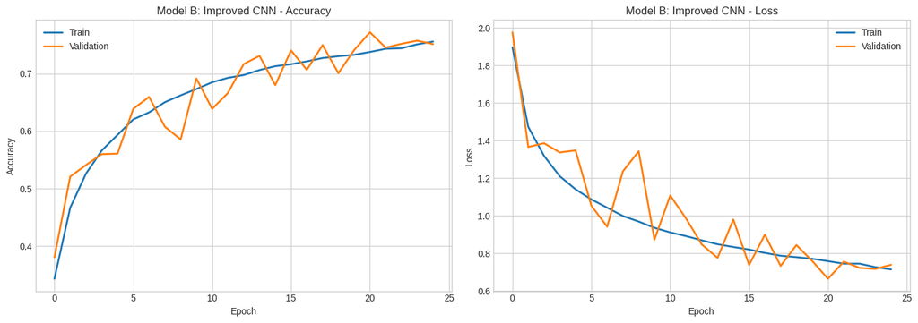

```
✅ Model B - Improved CNN Test Accuracy: 75.89% | Test Loss: 0.7227
```

```python
def build_improved_cnn(input_shape=(32, 32, 3), num_classes=10):
    inputs = keras.Input(shape=input_shape)

    # Block 1
    x = layers.Conv2D(32, (3, 3), padding='same')(inputs)
    x = layers.BatchNormalization()(x)
    x = layers.ReLU()(x)
    x = layers.Conv2D(32, (3, 3), padding='same')(x)
    x = layers.BatchNormalization()(x)
    x = layers.ReLU()(x)
    x = layers.MaxPooling2D((2, 2))(x)
    x = layers.Dropout(0.2)(x)

    # Block 2
    x = layers.Conv2D(64, (3, 3), padding='same')(x)
    x = layers.BatchNormalization()(x)
    x = layers.ReLU()(x)
    x = layers.Conv2D(64, (3, 3), padding='same')(x)
    x = layers.BatchNormalization()(x)
    x = layers.ReLU()(x)
    x = layers.MaxPooling2D((2, 2))(x)
    x = layers.Dropout(0.3)(x)

    # Block 3
    x = layers.Conv2D(128, (3, 3), padding='same')(x)
    x = layers.BatchNormalization()(x)
    x = layers.ReLU()(x)
    x = layers.Conv2D(128, (3, 3), padding='same')(x)
    x = layers.BatchNormalization()(x)
    x = layers.ReLU()(x)
    x = layers.MaxPooling2D((2, 2))(x)
    x = layers.Dropout(0.4)(x)

    # Classifier head
    x = layers.Flatten()(x)
    x = layers.Dense(256, activation='relu')(x)
    x = layers.BatchNormalization()(x)
    x = layers.Dropout(0.5)(x)
    outputs = layers.Dense(num_classes, activation='softmax')(x)

    return keras.Model(inputs, outputs, name="improved_cnn")


# Build, compile, and train
model_b = build_improved_cnn()
model_b.compile(
    optimizer=keras.optimizers.Adam(learning_rate=1e-3),
    loss='sparse_categorical_crossentropy',
    metrics=['accuracy']
)
model_b.summary()

history_b, time_b = train_model(model_b, train_ds, val_ds, epochs=25,
                                model_name="Model B - Improved CNN")
plot_history(history_b, "Model B: Improved CNN")
test_acc_b, test_loss_b = evaluate_model(model_b, test_ds, "Model B - Improved CNN")
```

## Model C: Residual CNN (ResNet-style)

This model uses **skip connections**. The key idea: the output of a block is `block(x) + x`. This helps gradients flow backward in deep networks, avoiding the "vanishing gradient" problem. This is the core idea behind ResNet, one of the most successful CNN architectures.

```
Model: "residual_cnn"
```

```
┏━━━━━━━━━━━━━━━━━━━━━┳━━━━━━━━━━━━━━━━━━━┳━━━━━━━━━━━━┳━━━━━━━━━━━━━━━━━━━┓
┃ Layer (type)        ┃ Output Shape      ┃    Param # ┃ Connected to      ┃
┡━━━━━━━━━━━━━━━━━━━━━╇━━━━━━━━━━━━━━━━━━━╇━━━━━━━━━━━━╇━━━━━━━━━━━━━━━━━━━┩
│ input_layer_3       │ (None, 32, 32, 3) │          0 │ -                 │
│ (InputLayer)        │                   │            │                   │
├─────────────────────┼───────────────────┼────────────┼───────────────────┤
│ conv2d_9 (Conv2D)   │ (None, 32, 32,    │        896 │ input_layer_3[0]… │
│                     │ 32)               │            │                   │
├─────────────────────┼───────────────────┼────────────┼───────────────────┤
│ batch_normalizatio… │ (None, 32, 32,    │        128 │ conv2d_9[0][0]    │
│ (BatchNormalizatio… │ 32)               │            │                   │
├─────────────────────┼───────────────────┼────────────┼───────────────────┤
│ re_lu_6 (ReLU)      │ (None, 32, 32,    │          0 │ batch_normalizat… │
│                     │ 32)               │            │                   │
├─────────────────────┼───────────────────┼────────────┼───────────────────┤
│ conv2d_10 (Conv2D)  │ (None, 32, 32,    │      9,248 │ re_lu_6[0][0]     │
│                     │ 32)               │            │                   │
├─────────────────────┼───────────────────┼────────────┼───────────────────┤
│ batch_normalizatio… │ (None, 32, 32,    │        128 │ conv2d_10[0][0]   │
│ (BatchNormalizatio… │ 32)               │            │                   │
├─────────────────────┼───────────────────┼────────────┼───────────────────┤
│ re_lu_7 (ReLU)      │ (None, 32, 32,    │          0 │ batch_normalizat… │
│                     │ 32)               │            │                   │
├─────────────────────┼───────────────────┼────────────┼───────────────────┤
│ conv2d_11 (Conv2D)  │ (None, 32, 32,    │      9,248 │ re_lu_7[0][0]     │
│                     │ 32)               │            │                   │
├─────────────────────┼───────────────────┼────────────┼───────────────────┤
│ batch_normalizatio… │ (None, 32, 32,    │        128 │ conv2d_11[0][0]   │
│ (BatchNormalizatio… │ 32)               │            │                   │
├─────────────────────┼───────────────────┼────────────┼───────────────────┤
│ add (Add)           │ (None, 32, 32,    │          0 │ batch_normalizat… │
│                     │ 32)               │            │ re_lu_6[0][0]     │
├─────────────────────┼───────────────────┼────────────┼───────────────────┤
│ re_lu_8 (ReLU)      │ (None, 32, 32,    │          0 │ add[0][0]         │
│                     │ 32)               │            │                   │
├─────────────────────┼───────────────────┼────────────┼───────────────────┤
│ conv2d_12 (Conv2D)  │ (None, 32, 32,    │      9,248 │ re_lu_8[0][0]     │
│                     │ 32)               │            │                   │
├─────────────────────┼───────────────────┼────────────┼───────────────────┤
│ batch_normalizatio… │ (None, 32, 32,    │        128 │ conv2d_12[0][0]   │
```

[output cut: 96 more lines]

```
│ batch_normalizatio… │ (None, 8, 8, 128) │        512 │ conv2d_23[0][0]   │
│ (BatchNormalizatio… │                   │            │                   │
├─────────────────────┼───────────────────┼────────────┼───────────────────┤
│ add_5 (Add)         │ (None, 8, 8, 128) │          0 │ batch_normalizat… │
│                     │                   │            │ re_lu_16[0][0]    │
├─────────────────────┼───────────────────┼────────────┼───────────────────┤
│ re_lu_18 (ReLU)     │ (None, 8, 8, 128) │          0 │ add_5[0][0]       │
├─────────────────────┼───────────────────┼────────────┼───────────────────┤
│ global_average_poo… │ (None, 128)       │          0 │ re_lu_18[0][0]    │
│ (GlobalAveragePool… │                   │            │                   │
├─────────────────────┼───────────────────┼────────────┼───────────────────┤
│ dropout_4 (Dropout) │ (None, 128)       │          0 │ global_average_p… │
├─────────────────────┼───────────────────┼────────────┼───────────────────┤
│ dense_4 (Dense)     │ (None, 10)        │      1,290 │ dropout_4[0][0]   │
└─────────────────────┴───────────────────┴────────────┴───────────────────┘
```

```
 Total params: 699,978 (2.67 MB)
```

```
 Trainable params: 697,738 (2.66 MB)
```

```
 Non-trainable params: 2,240 (8.75 KB)
```

```
============================================================
Training: Model C - Residual CNN
============================================================
704/704 ━━━━━━━━━━━━━━━━━━━━ 45s 40ms/step - accuracy: 0.3886 - loss: 1.7007 - val_accuracy: 0.4206 - val_loss: 1.8966
704/704 ━━━━━━━━━━━━━━━━━━━━ 19s 26ms/step - accuracy: 0.5244 - loss: 1.3189 - val_accuracy: 0.4796 - val_loss: 1.5752
704/704 ━━━━━━━━━━━━━━━━━━━━ 19s 26ms/step - accuracy: 0.5911 - loss: 1.1540 - val_accuracy: 0.5154 - val_loss: 1.5549
704/704 ━━━━━━━━━━━━━━━━━━━━ 18s 26ms/step - accuracy: 0.6354 - loss: 1.0389 - val_accuracy: 0.6240 - val_loss: 1.0975
704/704 ━━━━━━━━━━━━━━━━━━━━ 20s 25ms/step - accuracy: 0.6754 - loss: 0.9360 - val_accuracy: 0.5344 - val_loss: 1.4304
704/704 ━━━━━━━━━━━━━━━━━━━━ 19s 26ms/step - accuracy: 0.6952 - loss: 0.8793 - val_accuracy: 0.6892 - val_loss: 0.8983
704/704 ━━━━━━━━━━━━━━━━━━━━ 20s 25ms/step - accuracy: 0.7226 - loss: 0.8072 - val_accuracy: 0.6746 - val_loss: 0.9683
704/704 ━━━━━━━━━━━━━━━━━━━━ 19s 27ms/step - accuracy: 0.7378 - loss: 0.7660 - val_accuracy: 0.7112 - val_loss: 0.8140
704/704 ━━━━━━━━━━━━━━━━━━━━ 20s 25ms/step - accuracy: 0.7542 - loss: 0.7217 - val_accuracy: 0.7238 - val_loss: 0.8057
704/704 ━━━━━━━━━━━━━━━━━━━━ 19s 27ms/step - accuracy: 0.7646 - loss: 0.6881 - val_accuracy: 0.7526 - val_loss: 0.7208
704/704 ━━━━━━━━━━━━━━━━━━━━ 20s 25ms/step - accuracy: 0.7753 - loss: 0.6580 - val_accuracy: 0.7458 - val_loss: 0.7602
704/704 ━━━━━━━━━━━━━━━━━━━━ 19s 27ms/step - accuracy: 0.7846 - loss: 0.6339 - val_accuracy: 0.7258 - val_loss: 0.7900
704/704 ━━━━━━━━━━━━━━━━━━━━ 19s 25ms/step - accuracy: 0.7940 - loss: 0.6037 - val_accuracy: 0.7962 - val_loss: 0.5875
704/704 ━━━━━━━━━━━━━━━━━━━━ 19s 26ms/step - accuracy: 0.7998 - loss: 0.5880 - val_accuracy: 0.7768 - val_loss: 0.6528
704/704 ━━━━━━━━━━━━━━━━━━━━ 18s 25ms/step - accuracy: 0.8077 - loss: 0.5653 - val_accuracy: 0.7796 - val_loss: 0.6383
704/704 ━━━━━━━━━━━━━━━━━━━━ 21s 26ms/step - accuracy: 0.8104 - loss: 0.5564 - val_accuracy: 0.7822 - val_loss: 0.6655
704/704 ━━━━━━━━━━━━━━━━━━━━ 20s 25ms/step - accuracy: 0.8184 - loss: 0.5355 - val_accuracy: 0.7776 - val_loss: 0.6420
704/704 ━━━━━━━━━━━━━━━━━━━━ 19s 26ms/step - accuracy: 0.8240 - loss: 0.5202 - val_accuracy: 0.7504 - val_loss: 0.7860
Epoch 18: early stopping
Restoring model weights from the end of the best epoch: 13.

⏱️ Training time: 372.8 seconds
```

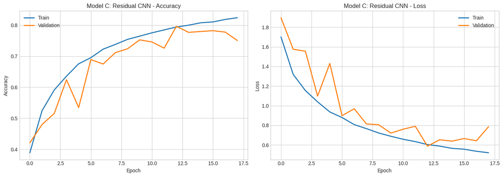

```
✅ Model C - Residual CNN Test Accuracy: 79.47% | Test Loss: 0.5992
```

```python
def residual_block(x, filters, stride=1):
    """A single residual block with skip connection."""
    shortcut = x

    # Main path
    x = layers.Conv2D(filters, (3, 3), strides=stride, padding='same')(x)
    x = layers.BatchNormalization()(x)
    x = layers.ReLU()(x)

    x = layers.Conv2D(filters, (3, 3), padding='same')(x)
    x = layers.BatchNormalization()(x)

    # If shape changed (stride > 1 or different filters), project the shortcut
    if stride != 1 or shortcut.shape[-1] != filters:
        shortcut = layers.Conv2D(filters, (1, 1), strides=stride, padding='same')(shortcut)
        shortcut = layers.BatchNormalization()(shortcut)

    # Add skip connection
    x = layers.Add()([x, shortcut])
    x = layers.ReLU()(x)
    return x


def build_residual_cnn(input_shape=(32, 32, 3), num_classes=10):
    inputs = keras.Input(shape=input_shape)

    # Initial conv
    x = layers.Conv2D(32, (3, 3), padding='same')(inputs)
    x = layers.BatchNormalization()(x)
    x = layers.ReLU()(x)

    # Stage 1: two residual blocks with 32 filters
    x = residual_block(x, 32)
    x = residual_block(x, 32)

    # Stage 2: two residual blocks with 64 filters (downsample)
    x = residual_block(x, 64, stride=2)
    x = residual_block(x, 64)

    # Stage 3: two residual blocks with 128 filters (downsample)
    x = residual_block(x, 128, stride=2)
    x = residual_block(x, 128)

    # Classifier head
    x = layers.GlobalAveragePooling2D()(x)
    x = layers.Dropout(0.4)(x)
    outputs = layers.Dense(num_classes, activation='softmax')(x)

    return keras.Model(inputs, outputs, name="residual_cnn")


# Build, compile, and train
model_c = build_residual_cnn()
model_c.compile(
    optimizer=keras.optimizers.Adam(learning_rate=1e-3),
    loss='sparse_categorical_crossentropy',
    metrics=['accuracy']
)
model_c.summary()

history_c, time_c = train_model(model_c, train_ds, val_ds, epochs=25,
                                model_name="Model C - Residual CNN")
plot_history(history_c, "Model C: Residual CNN")
test_acc_c, test_loss_c = evaluate_model(model_c, test_ds, "Model C - Residual CNN")
```

```
Custom CNN Models Comparison:

                   Model  Parameters  Train Accuracy  Val Accuracy  Test Accuracy  Training Time (s)
             A: Baseline      356810          0.6941        0.7222         0.7124              264.7
B: Improved (BN+Dropout)      816938          0.7560        0.7722         0.7589              437.8
             C: Residual      699978          0.8240        0.7962         0.7947              372.8
```

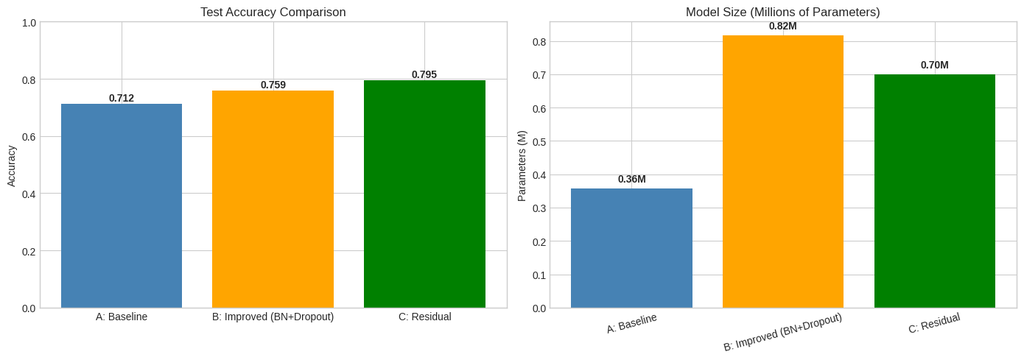

```python
# Build comparison table
comparison_df = pd.DataFrame({
    'Model': ['A: Baseline', 'B: Improved (BN+Dropout)', 'C: Residual'],
    'Parameters': [model_a.count_params(), model_b.count_params(), model_c.count_params()],
    'Train Accuracy': [history_a.history['accuracy'][-1],
                       history_b.history['accuracy'][-1],
                       history_c.history['accuracy'][-1]],
    'Val Accuracy': [max(history_a.history['val_accuracy']),
                     max(history_b.history['val_accuracy']),
                     max(history_c.history['val_accuracy'])],
    'Test Accuracy': [test_acc_a, test_acc_b, test_acc_c],
    'Training Time (s)': [time_a, time_b, time_c]
})

# Round for readability
comparison_df['Train Accuracy'] = comparison_df['Train Accuracy'].round(4)
comparison_df['Val Accuracy'] = comparison_df['Val Accuracy'].round(4)
comparison_df['Test Accuracy'] = comparison_df['Test Accuracy'].round(4)
comparison_df['Training Time (s)'] = comparison_df['Training Time (s)'].round(1)

print("Custom CNN Models Comparison:\n")
print(comparison_df.to_string(index=False))

# Plot comparison bar chart
fig, axes = plt.subplots(1, 2, figsize=(14, 5))

# Test accuracy bar chart
axes[0].bar(comparison_df['Model'], comparison_df['Test Accuracy'],
            color=['steelblue', 'orange', 'green'])
axes[0].set_title('Test Accuracy Comparison')
axes[0].set_ylabel('Accuracy')
axes[0].set_ylim([0, 1])
for i, v in enumerate(comparison_df['Test Accuracy']):
    axes[0].text(i, v + 0.01, f'{v:.3f}', ha='center', fontweight='bold')

# Parameters bar chart
axes[1].bar(comparison_df['Model'], comparison_df['Parameters'] / 1e6,
            color=['steelblue', 'orange', 'green'])
axes[1].set_title('Model Size (Millions of Parameters)')
axes[1].set_ylabel('Parameters (M)')
for i, v in enumerate(comparison_df['Parameters']):
    axes[1].text(i, v/1e6 + 0.02, f'{v/1e6:.2f}M', ha='center', fontweight='bold')

plt.xticks(rotation=15)
plt.tight_layout()
plt.show()
```

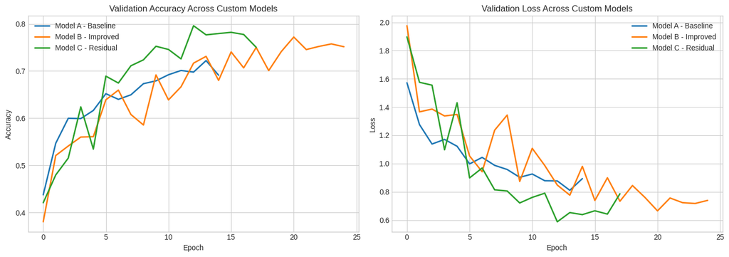

```python
# Plot all 3 models' validation accuracy on one chart
plt.figure(figsize=(14, 5))

plt.subplot(1, 2, 1)
plt.plot(history_a.history['val_accuracy'], label='Model A - Baseline', linewidth=2)
plt.plot(history_b.history['val_accuracy'], label='Model B - Improved', linewidth=2)
plt.plot(history_c.history['val_accuracy'], label='Model C - Residual', linewidth=2)
plt.title('Validation Accuracy Across Custom Models')
plt.xlabel('Epoch')
plt.ylabel('Accuracy')
plt.legend()
plt.grid(True)

plt.subplot(1, 2, 2)
plt.plot(history_a.history['val_loss'], label='Model A - Baseline', linewidth=2)
plt.plot(history_b.history['val_loss'], label='Model B - Improved', linewidth=2)
plt.plot(history_c.history['val_loss'], label='Model C - Residual', linewidth=2)
plt.title('Validation Loss Across Custom Models')
plt.xlabel('Epoch')
plt.ylabel('Loss')
plt.legend()
plt.grid(True)

plt.tight_layout()
plt.show()
```

### Part 2 Summary

**Actual results:**

| Model | Parameters | Test Accuracy | Notes |
| --- | --- | --- | --- |
| A: Baseline | 357K | 71.24% | Simple 3-block CNN, no regularization |
| B: Improved (BN+Dropout) | 817K | 75.89% | Underfit slightly — could use more epochs |
| C: Residual (ResNet-style) | 700K | **79.47%** 🏆 | Best custom model |

**Key findings:**

**Best custom model:** Model C (Residual CNN) at **79.47% test accuracy**.

**Lesson learned:** Architectural choices (residual connections, global average pooling) matter more than just "adding more layers". However, even our best custom model is outperformed by transfer learning (Part 3) — modern practice favors starting with pretrained weights when possible.

# Part 3: Transfer Learning Implementation (15 points)

In this section, we use **3 pre-trained models** from ImageNet and adapt them to CIFAR-10:

1. **VGG16** — classic, deep network with small 3×3 filters
2. **ResNet50** — uses residual connections, very deep (50 layers)
3. **EfficientNetB0** — modern, compound-scaled architecture

For **each** model, we try **two strategies**:

- **Feature Extraction**: freeze the pre-trained layers, only train a new classifier head
- **Fine-tuning**: unfreeze the top few layers and train with a very small learning rate

**Why resize images?** CIFAR-10 is 32×32 but these pre-trained models expect 96×96 or bigger. We use a `Resizing` layer to upscale before feeding into the base model.

**Why small learning rate for fine-tuning?** Pre-trained weights are already good. We just want to nudge them — not destroy them.

```python
# Pre-trained models need bigger images
TL_IMAGE_SIZE = 96
TL_BATCH_SIZE = 64

# Build separate data pipelines WITHOUT pre-normalizing
# (each pre-trained model has its own preprocessing function)
train_ds_tl = tf.data.Dataset.from_tensor_slices((X_train.astype('float32'), y_train))
train_ds_tl = train_ds_tl.shuffle(1000, seed=SEED).batch(TL_BATCH_SIZE).prefetch(AUTOTUNE)

val_ds_tl = tf.data.Dataset.from_tensor_slices((X_val.astype('float32'), y_val))
val_ds_tl = val_ds_tl.batch(TL_BATCH_SIZE).prefetch(AUTOTUNE)

test_ds_tl = tf.data.Dataset.from_tensor_slices((X_test.astype('float32'), y_test))
test_ds_tl = test_ds_tl.batch(TL_BATCH_SIZE).prefetch(AUTOTUNE)

print(f"✅ Transfer learning pipelines ready")
print(f"   Image size for pre-trained models: {TL_IMAGE_SIZE}x{TL_IMAGE_SIZE}")
print(f"   Batch size: {TL_BATCH_SIZE}")


# Build a FRESH augmentation pipeline for transfer learning
# (without fixed input shape — so it works on any size)
tl_augmentation = keras.Sequential([
    layers.RandomFlip("horizontal"),
    layers.RandomRotation(0.1),
    layers.RandomZoom(0.1),
    layers.RandomContrast(0.1),
], name="tl_augmentation")


# Generic function to build a transfer learning model
def build_tl_model(base_model_class, preprocess_fn, base_name,
                   image_size=TL_IMAGE_SIZE, num_classes=10,
                   trainable_base=False, unfreeze_last_n=0):
    """
    Build a transfer learning model.
    - base_model_class: the Keras application (e.g., keras.applications.VGG16)
    - preprocess_fn: the matching preprocess_input function
    - trainable_base: if True, fine-tuning mode; if False, feature extraction mode
    - unfreeze_last_n: number of top layers to unfreeze (only used if trainable_base=True)
    """
    inputs = keras.Input(shape=(32, 32, 3))

    # Apply augmentation on 32x32 images FIRST (before resizing)
    x = tl_augmentation(inputs)

    # Resize to match pre-trained input size
    x = layers.Resizing(image_size, image_size)(x)

    # Apply model-specific preprocessing (scales pixels the way the base expects)
    x = layers.Lambda(preprocess_fn)(x)

    # Load pre-trained base (without top classifier)
    base_model = base_model_class(
        include_top=False,
        weights='imagenet',
        input_shape=(image_size, image_size, 3)
    )

    # Freeze everything first
    base_model.trainable = False

    # If fine-tuning, unfreeze last N layers
    if trainable_base and unfreeze_last_n > 0:
        base_model.trainable = True
        for layer in base_model.layers[:-unfreeze_last_n]:
            layer.trainable = False

    x = base_model(x, training=False)
    x = layers.GlobalAveragePooling2D()(x)
    x = layers.Dropout(0.3)(x)
    x = layers.Dense(128, activation='relu')(x)
    x = layers.Dropout(0.3)(x)
    outputs = layers.Dense(num_classes, activation='softmax')(x)

    model = keras.Model(inputs, outputs, name=f"tl_{base_name}")
    return model, base_model


# Storage for results
tl_results = []
```

```
✅ Transfer learning pipelines ready
   Image size for pre-trained models: 96x96
   Batch size: 64
```

## Experiment 1: VGG16 — Feature Extraction

Freeze all VGG16 layers. Only train the classifier head on top. This treats VGG16 as a fixed feature extractor.

```
Downloading data from https://storage.googleapis.com/tensorflow/keras-applications/vgg16/vgg16_weights_tf_dim_ordering_tf_kernels_notop.h5
58889256/58889256 ━━━━━━━━━━━━━━━━━━━━ 0s 0us/step
VGG16 Feature Extraction — Total params: 14,781,642
Trainable params: 66,954

============================================================
Training: VGG16 Feature Extraction
============================================================
704/704 ━━━━━━━━━━━━━━━━━━━━ 49s 63ms/step - accuracy: 0.4660 - loss: 1.7988 - val_accuracy: 0.7390 - val_loss: 0.7640
704/704 ━━━━━━━━━━━━━━━━━━━━ 43s 61ms/step - accuracy: 0.5849 - loss: 1.1935 - val_accuracy: 0.7702 - val_loss: 0.6590
704/704 ━━━━━━━━━━━━━━━━━━━━ 43s 61ms/step - accuracy: 0.6168 - loss: 1.1065 - val_accuracy: 0.7770 - val_loss: 0.6385
704/704 ━━━━━━━━━━━━━━━━━━━━ 43s 61ms/step - accuracy: 0.6316 - loss: 1.0552 - val_accuracy: 0.7904 - val_loss: 0.6143
704/704 ━━━━━━━━━━━━━━━━━━━━ 43s 61ms/step - accuracy: 0.6406 - loss: 1.0395 - val_accuracy: 0.7958 - val_loss: 0.6061
704/704 ━━━━━━━━━━━━━━━━━━━━ 43s 61ms/step - accuracy: 0.6460 - loss: 1.0272 - val_accuracy: 0.7990 - val_loss: 0.5839
704/704 ━━━━━━━━━━━━━━━━━━━━ 43s 61ms/step - accuracy: 0.6472 - loss: 1.0151 - val_accuracy: 0.7964 - val_loss: 0.5953
704/704 ━━━━━━━━━━━━━━━━━━━━ 43s 61ms/step - accuracy: 0.6531 - loss: 0.9978 - val_accuracy: 0.8090 - val_loss: 0.5713
704/704 ━━━━━━━━━━━━━━━━━━━━ 43s 61ms/step - accuracy: 0.6588 - loss: 0.9898 - val_accuracy: 0.8070 - val_loss: 0.5671
704/704 ━━━━━━━━━━━━━━━━━━━━ 43s 61ms/step - accuracy: 0.6612 - loss: 0.9773 - val_accuracy: 0.8088 - val_loss: 0.5640
Restoring model weights from the end of the best epoch: 10.

⏱️ Training time: 434.7 seconds
✅ VGG16 Feature Extraction Test Accuracy: 80.31% | Test Loss: 0.5806
```

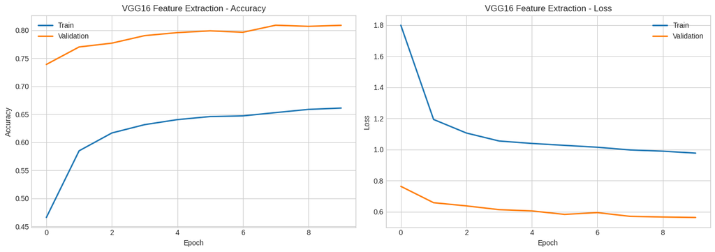

```python
model_vgg_fe, base_vgg = build_tl_model(
    base_model_class=keras.applications.VGG16,
    preprocess_fn=keras.applications.vgg16.preprocess_input,
    base_name="vgg16_feature_extract",
    trainable_base=False
)

model_vgg_fe.compile(
    optimizer=keras.optimizers.Adam(learning_rate=1e-3),
    loss='sparse_categorical_crossentropy',
    metrics=['accuracy']
)

print(f"VGG16 Feature Extraction — Total params: {model_vgg_fe.count_params():,}")
print(f"Trainable params: {sum([tf.size(v).numpy() for v in model_vgg_fe.trainable_variables]):,}")

history_vgg_fe, time_vgg_fe = train_model(
    model_vgg_fe, train_ds_tl, val_ds_tl, epochs=10,
    model_name="VGG16 Feature Extraction"
)
test_acc_vgg_fe, _ = evaluate_model(model_vgg_fe, test_ds_tl, "VGG16 Feature Extraction")

tl_results.append({
    'Model': 'VGG16',
    'Strategy': 'Feature Extraction',
    'Test Accuracy': test_acc_vgg_fe,
    'Training Time (s)': time_vgg_fe,
    'Parameters': model_vgg_fe.count_params()
})
plot_history(history_vgg_fe, "VGG16 Feature Extraction")
```

## Experiment 2: VGG16 — Fine-Tuning

Unfreeze the **last 4 layers** of VGG16 and train with a very small learning rate (1e-5). This lets the top layers adapt slightly to CIFAR-10 while keeping early layers stable.

```
VGG16 Fine-Tuning — Trainable params: 7,146,378

============================================================
Training: VGG16 Fine-Tuning
============================================================
704/704 ━━━━━━━━━━━━━━━━━━━━ 58s 77ms/step - accuracy: 0.2246 - loss: 2.3547 - val_accuracy: 0.5532 - val_loss: 1.3476
704/704 ━━━━━━━━━━━━━━━━━━━━ 54s 76ms/step - accuracy: 0.4766 - loss: 1.5261 - val_accuracy: 0.7338 - val_loss: 0.8341
704/704 ━━━━━━━━━━━━━━━━━━━━ 54s 77ms/step - accuracy: 0.6094 - loss: 1.1688 - val_accuracy: 0.7946 - val_loss: 0.6522
704/704 ━━━━━━━━━━━━━━━━━━━━ 54s 77ms/step - accuracy: 0.6750 - loss: 0.9866 - val_accuracy: 0.8280 - val_loss: 0.5494
704/704 ━━━━━━━━━━━━━━━━━━━━ 54s 77ms/step - accuracy: 0.7191 - loss: 0.8666 - val_accuracy: 0.8358 - val_loss: 0.5136
704/704 ━━━━━━━━━━━━━━━━━━━━ 54s 76ms/step - accuracy: 0.7465 - loss: 0.7813 - val_accuracy: 0.8526 - val_loss: 0.4636
704/704 ━━━━━━━━━━━━━━━━━━━━ 54s 76ms/step - accuracy: 0.7660 - loss: 0.7213 - val_accuracy: 0.8592 - val_loss: 0.4383
704/704 ━━━━━━━━━━━━━━━━━━━━ 83s 77ms/step - accuracy: 0.7847 - loss: 0.6683 - val_accuracy: 0.8698 - val_loss: 0.4038
704/704 ━━━━━━━━━━━━━━━━━━━━ 53s 76ms/step - accuracy: 0.7992 - loss: 0.6234 - val_accuracy: 0.8782 - val_loss: 0.3858
704/704 ━━━━━━━━━━━━━━━━━━━━ 54s 77ms/step - accuracy: 0.8069 - loss: 0.5989 - val_accuracy: 0.8740 - val_loss: 0.3941
Restoring model weights from the end of the best epoch: 9.

⏱️ Training time: 570.8 seconds
✅ VGG16 Fine-Tuning Test Accuracy: 87.63% | Test Loss: 0.4024
```

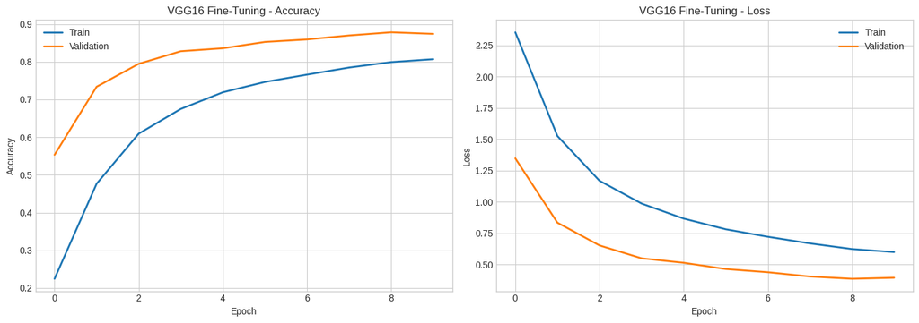

```python
model_vgg_ft, _ = build_tl_model(
    base_model_class=keras.applications.VGG16,
    preprocess_fn=keras.applications.vgg16.preprocess_input,
    base_name="vgg16_finetune",
    trainable_base=True,
    unfreeze_last_n=4
)

model_vgg_ft.compile(
    optimizer=keras.optimizers.Adam(learning_rate=1e-5),  # Much smaller!
    loss='sparse_categorical_crossentropy',
    metrics=['accuracy']
)

print(f"VGG16 Fine-Tuning — Trainable params: {sum([tf.size(v).numpy() for v in model_vgg_ft.trainable_variables]):,}")

history_vgg_ft, time_vgg_ft = train_model(
    model_vgg_ft, train_ds_tl, val_ds_tl, epochs=10,
    model_name="VGG16 Fine-Tuning"
)
test_acc_vgg_ft, _ = evaluate_model(model_vgg_ft, test_ds_tl, "VGG16 Fine-Tuning")

tl_results.append({
    'Model': 'VGG16',
    'Strategy': 'Fine-Tuning',
    'Test Accuracy': test_acc_vgg_ft,
    'Training Time (s)': time_vgg_ft,
    'Parameters': model_vgg_ft.count_params()
})
plot_history(history_vgg_ft, "VGG16 Fine-Tuning")
```

## Experiment 3: ResNet50 — Feature Extraction

```
Downloading data from https://storage.googleapis.com/tensorflow/keras-applications/resnet/resnet50_weights_tf_dim_ordering_tf_kernels_notop.h5
94765736/94765736 ━━━━━━━━━━━━━━━━━━━━ 0s 0us/step
ResNet50 Feature Extraction — Total params: 23,851,274

============================================================
Training: ResNet50 Feature Extraction
============================================================
704/704 ━━━━━━━━━━━━━━━━━━━━ 56s 68ms/step - accuracy: 0.6429 - loss: 1.0539 - val_accuracy: 0.8332 - val_loss: 0.4966
704/704 ━━━━━━━━━━━━━━━━━━━━ 45s 64ms/step - accuracy: 0.7001 - loss: 0.8586 - val_accuracy: 0.8368 - val_loss: 0.4659
704/704 ━━━━━━━━━━━━━━━━━━━━ 46s 65ms/step - accuracy: 0.7237 - loss: 0.8053 - val_accuracy: 0.8466 - val_loss: 0.4496
704/704 ━━━━━━━━━━━━━━━━━━━━ 46s 65ms/step - accuracy: 0.7320 - loss: 0.7778 - val_accuracy: 0.8596 - val_loss: 0.4208
704/704 ━━━━━━━━━━━━━━━━━━━━ 45s 65ms/step - accuracy: 0.7368 - loss: 0.7584 - val_accuracy: 0.8604 - val_loss: 0.4251
704/704 ━━━━━━━━━━━━━━━━━━━━ 45s 65ms/step - accuracy: 0.7394 - loss: 0.7441 - val_accuracy: 0.8532 - val_loss: 0.4178
704/704 ━━━━━━━━━━━━━━━━━━━━ 45s 64ms/step - accuracy: 0.7425 - loss: 0.7431 - val_accuracy: 0.8448 - val_loss: 0.4405
704/704 ━━━━━━━━━━━━━━━━━━━━ 46s 65ms/step - accuracy: 0.7512 - loss: 0.7239 - val_accuracy: 0.8598 - val_loss: 0.4090
704/704 ━━━━━━━━━━━━━━━━━━━━ 45s 64ms/step - accuracy: 0.7480 - loss: 0.7209 - val_accuracy: 0.8610 - val_loss: 0.4066
704/704 ━━━━━━━━━━━━━━━━━━━━ 45s 64ms/step - accuracy: 0.7501 - loss: 0.7133 - val_accuracy: 0.8632 - val_loss: 0.4036
Restoring model weights from the end of the best epoch: 10.

⏱️ Training time: 465.5 seconds
✅ ResNet50 Feature Extraction Test Accuracy: 85.32% | Test Loss: 0.4242
```

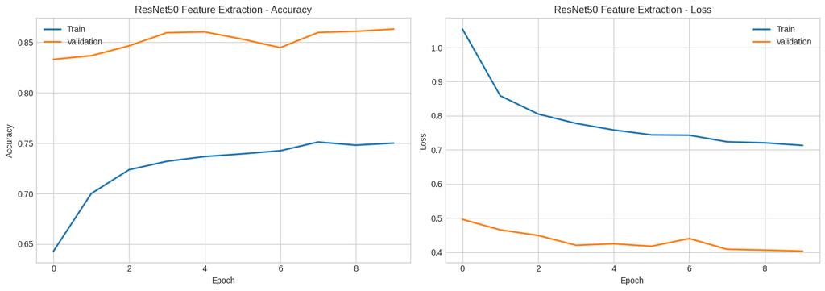

```python
model_resnet_fe, _ = build_tl_model(
    base_model_class=keras.applications.ResNet50,
    preprocess_fn=keras.applications.resnet50.preprocess_input,
    base_name="resnet50_feature_extract",
    trainable_base=False
)

model_resnet_fe.compile(
    optimizer=keras.optimizers.Adam(learning_rate=1e-3),
    loss='sparse_categorical_crossentropy',
    metrics=['accuracy']
)

print(f"ResNet50 Feature Extraction — Total params: {model_resnet_fe.count_params():,}")

history_resnet_fe, time_resnet_fe = train_model(
    model_resnet_fe, train_ds_tl, val_ds_tl, epochs=10,
    model_name="ResNet50 Feature Extraction"
)
test_acc_resnet_fe, _ = evaluate_model(model_resnet_fe, test_ds_tl, "ResNet50 Feature Extraction")

tl_results.append({
    'Model': 'ResNet50',
    'Strategy': 'Feature Extraction',
    'Test Accuracy': test_acc_resnet_fe,
    'Training Time (s)': time_resnet_fe,
    'Parameters': model_resnet_fe.count_params()
})
plot_history(history_resnet_fe, "ResNet50 Feature Extraction")
```

## Experiment 4: ResNet50 — Fine-Tuning

Unfreeze the **last 20 layers** (roughly the last residual block) with a very small learning rate.

```
ResNet50 Fine-Tuning — Trainable params: 9,194,890

============================================================
Training: ResNet50 Fine-Tuning
============================================================
704/704 ━━━━━━━━━━━━━━━━━━━━ 72s 87ms/step - accuracy: 0.3315 - loss: 2.1830 - val_accuracy: 0.7358 - val_loss: 0.8216
704/704 ━━━━━━━━━━━━━━━━━━━━ 58s 83ms/step - accuracy: 0.5798 - loss: 1.2530 - val_accuracy: 0.8078 - val_loss: 0.5836
704/704 ━━━━━━━━━━━━━━━━━━━━ 58s 83ms/step - accuracy: 0.6687 - loss: 0.9906 - val_accuracy: 0.8324 - val_loss: 0.5014
704/704 ━━━━━━━━━━━━━━━━━━━━ 58s 83ms/step - accuracy: 0.7069 - loss: 0.8756 - val_accuracy: 0.8486 - val_loss: 0.4518
704/704 ━━━━━━━━━━━━━━━━━━━━ 59s 83ms/step - accuracy: 0.7335 - loss: 0.7932 - val_accuracy: 0.8564 - val_loss: 0.4221
704/704 ━━━━━━━━━━━━━━━━━━━━ 58s 83ms/step - accuracy: 0.7526 - loss: 0.7358 - val_accuracy: 0.8644 - val_loss: 0.3972
704/704 ━━━━━━━━━━━━━━━━━━━━ 58s 83ms/step - accuracy: 0.7694 - loss: 0.6867 - val_accuracy: 0.8762 - val_loss: 0.3790
704/704 ━━━━━━━━━━━━━━━━━━━━ 58s 83ms/step - accuracy: 0.7843 - loss: 0.6412 - val_accuracy: 0.8802 - val_loss: 0.3626
704/704 ━━━━━━━━━━━━━━━━━━━━ 58s 83ms/step - accuracy: 0.7944 - loss: 0.6119 - val_accuracy: 0.8844 - val_loss: 0.3503
704/704 ━━━━━━━━━━━━━━━━━━━━ 58s 83ms/step - accuracy: 0.8012 - loss: 0.5879 - val_accuracy: 0.8854 - val_loss: 0.3399
Restoring model weights from the end of the best epoch: 10.

⏱️ Training time: 597.5 seconds
✅ ResNet50 Fine-Tuning Test Accuracy: 88.00% | Test Loss: 0.3560
```

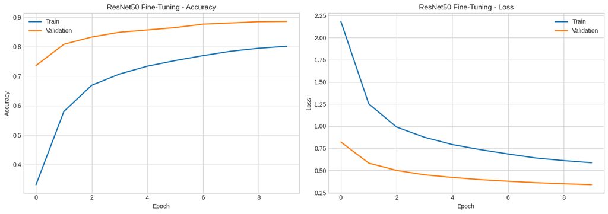

```python
model_resnet_ft, _ = build_tl_model(
    base_model_class=keras.applications.ResNet50,
    preprocess_fn=keras.applications.resnet50.preprocess_input,
    base_name="resnet50_finetune",
    trainable_base=True,
    unfreeze_last_n=20
)

model_resnet_ft.compile(
    optimizer=keras.optimizers.Adam(learning_rate=1e-5),
    loss='sparse_categorical_crossentropy',
    metrics=['accuracy']
)

print(f"ResNet50 Fine-Tuning — Trainable params: {sum([tf.size(v).numpy() for v in model_resnet_ft.trainable_variables]):,}")

history_resnet_ft, time_resnet_ft = train_model(
    model_resnet_ft, train_ds_tl, val_ds_tl, epochs=10,
    model_name="ResNet50 Fine-Tuning"
)
test_acc_resnet_ft, _ = evaluate_model(model_resnet_ft, test_ds_tl, "ResNet50 Fine-Tuning")

tl_results.append({
    'Model': 'ResNet50',
    'Strategy': 'Fine-Tuning',
    'Test Accuracy': test_acc_resnet_ft,
    'Training Time (s)': time_resnet_ft,
    'Parameters': model_resnet_ft.count_params()
})
plot_history(history_resnet_ft, "ResNet50 Fine-Tuning")
```

## Experiment 5: EfficientNetB0 — Feature Extraction

EfficientNetB0 is the newest of the three. It balances depth, width, and resolution using "compound scaling". It has fewer parameters than VGG or ResNet but often gets higher accuracy.

```
Downloading data from https://storage.googleapis.com/keras-applications/efficientnetb0_notop.h5
16705208/16705208 ━━━━━━━━━━━━━━━━━━━━ 0s 0us/step
EfficientNetB0 Feature Extraction — Total params: 4,214,829

============================================================
Training: EfficientNetB0 Feature Extraction
============================================================
704/704 ━━━━━━━━━━━━━━━━━━━━ 40s 41ms/step - accuracy: 0.6306 - loss: 1.0574 - val_accuracy: 0.8318 - val_loss: 0.5198
704/704 ━━━━━━━━━━━━━━━━━━━━ 26s 37ms/step - accuracy: 0.6910 - loss: 0.8901 - val_accuracy: 0.8450 - val_loss: 0.4798
704/704 ━━━━━━━━━━━━━━━━━━━━ 25s 36ms/step - accuracy: 0.6984 - loss: 0.8630 - val_accuracy: 0.8410 - val_loss: 0.4702
704/704 ━━━━━━━━━━━━━━━━━━━━ 25s 36ms/step - accuracy: 0.7091 - loss: 0.8392 - val_accuracy: 0.8480 - val_loss: 0.4554
704/704 ━━━━━━━━━━━━━━━━━━━━ 25s 36ms/step - accuracy: 0.7108 - loss: 0.8285 - val_accuracy: 0.8474 - val_loss: 0.4445
704/704 ━━━━━━━━━━━━━━━━━━━━ 26s 36ms/step - accuracy: 0.7148 - loss: 0.8201 - val_accuracy: 0.8534 - val_loss: 0.4439
704/704 ━━━━━━━━━━━━━━━━━━━━ 25s 36ms/step - accuracy: 0.7175 - loss: 0.8118 - val_accuracy: 0.8534 - val_loss: 0.4391
704/704 ━━━━━━━━━━━━━━━━━━━━ 25s 36ms/step - accuracy: 0.7238 - loss: 0.7987 - val_accuracy: 0.8566 - val_loss: 0.4315
704/704 ━━━━━━━━━━━━━━━━━━━━ 25s 36ms/step - accuracy: 0.7218 - loss: 0.7963 - val_accuracy: 0.8578 - val_loss: 0.4296
704/704 ━━━━━━━━━━━━━━━━━━━━ 25s 36ms/step - accuracy: 0.7235 - loss: 0.7922 - val_accuracy: 0.8554 - val_loss: 0.4259
Restoring model weights from the end of the best epoch: 10.

⏱️ Training time: 269.3 seconds
✅ EfficientNetB0 Feature Extraction Test Accuracy: 85.23% | Test Loss: 0.4468
```

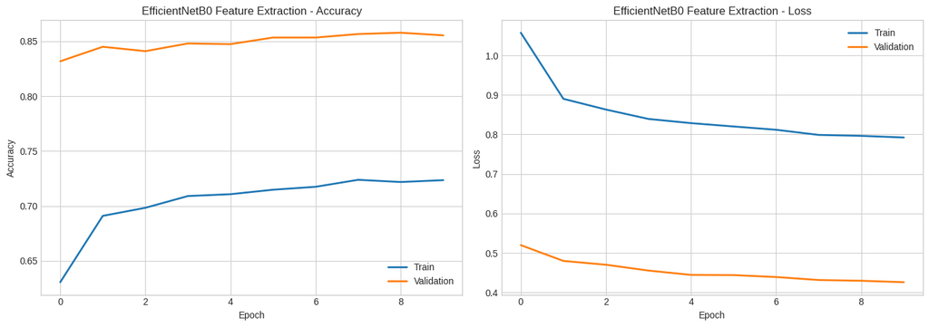

```python
model_eff_fe, _ = build_tl_model(
    base_model_class=keras.applications.EfficientNetB0,
    preprocess_fn=keras.applications.efficientnet.preprocess_input,
    base_name="efficientnet_feature_extract",
    trainable_base=False
)

model_eff_fe.compile(
    optimizer=keras.optimizers.Adam(learning_rate=1e-3),
    loss='sparse_categorical_crossentropy',
    metrics=['accuracy']
)

print(f"EfficientNetB0 Feature Extraction — Total params: {model_eff_fe.count_params():,}")

history_eff_fe, time_eff_fe = train_model(
    model_eff_fe, train_ds_tl, val_ds_tl, epochs=10,
    model_name="EfficientNetB0 Feature Extraction"
)
test_acc_eff_fe, _ = evaluate_model(model_eff_fe, test_ds_tl, "EfficientNetB0 Feature Extraction")

tl_results.append({
    'Model': 'EfficientNetB0',
    'Strategy': 'Feature Extraction',
    'Test Accuracy': test_acc_eff_fe,
    'Training Time (s)': time_eff_fe,
    'Parameters': model_eff_fe.count_params()
})
plot_history(history_eff_fe, "EfficientNetB0 Feature Extraction")
```

## Experiment 6: EfficientNetB0 — Fine-Tuning

Unfreeze the **last 20 layers** with a small learning rate.

```
EfficientNetB0 Fine-Tuning — Trainable params: 1,516,218

============================================================
Training: EfficientNetB0 Fine-Tuning
============================================================
704/704 ━━━━━━━━━━━━━━━━━━━━ 47s 49ms/step - accuracy: 0.2287 - loss: 2.1665 - val_accuracy: 0.5554 - val_loss: 1.5470
704/704 ━━━━━━━━━━━━━━━━━━━━ 30s 42ms/step - accuracy: 0.4465 - loss: 1.6263 - val_accuracy: 0.7248 - val_loss: 1.0375
704/704 ━━━━━━━━━━━━━━━━━━━━ 30s 42ms/step - accuracy: 0.5511 - loss: 1.3298 - val_accuracy: 0.7730 - val_loss: 0.7960
704/704 ━━━━━━━━━━━━━━━━━━━━ 29s 42ms/step - accuracy: 0.6022 - loss: 1.1773 - val_accuracy: 0.7960 - val_loss: 0.6744
704/704 ━━━━━━━━━━━━━━━━━━━━ 29s 41ms/step - accuracy: 0.6336 - loss: 1.0745 - val_accuracy: 0.8140 - val_loss: 0.6012
704/704 ━━━━━━━━━━━━━━━━━━━━ 29s 42ms/step - accuracy: 0.6606 - loss: 1.0060 - val_accuracy: 0.8276 - val_loss: 0.5525
704/704 ━━━━━━━━━━━━━━━━━━━━ 29s 41ms/step - accuracy: 0.6737 - loss: 0.9583 - val_accuracy: 0.8352 - val_loss: 0.5193
704/704 ━━━━━━━━━━━━━━━━━━━━ 29s 42ms/step - accuracy: 0.6885 - loss: 0.9127 - val_accuracy: 0.8412 - val_loss: 0.4918
704/704 ━━━━━━━━━━━━━━━━━━━━ 29s 42ms/step - accuracy: 0.7017 - loss: 0.8897 - val_accuracy: 0.8454 - val_loss: 0.4712
704/704 ━━━━━━━━━━━━━━━━━━━━ 41s 42ms/step - accuracy: 0.7088 - loss: 0.8541 - val_accuracy: 0.8498 - val_loss: 0.4556
Restoring model weights from the end of the best epoch: 10.

⏱️ Training time: 323.3 seconds
✅ EfficientNetB0 Fine-Tuning Test Accuracy: 84.28% | Test Loss: 0.4697
```

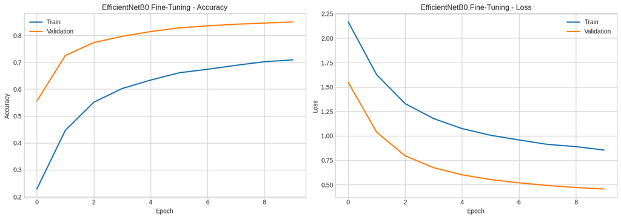

```python
model_eff_ft, _ = build_tl_model(
    base_model_class=keras.applications.EfficientNetB0,
    preprocess_fn=keras.applications.efficientnet.preprocess_input,
    base_name="efficientnet_finetune",
    trainable_base=True,
    unfreeze_last_n=20
)

model_eff_ft.compile(
    optimizer=keras.optimizers.Adam(learning_rate=1e-5),
    loss='sparse_categorical_crossentropy',
    metrics=['accuracy']
)

print(f"EfficientNetB0 Fine-Tuning — Trainable params: {sum([tf.size(v).numpy() for v in model_eff_ft.trainable_variables]):,}")

history_eff_ft, time_eff_ft = train_model(
    model_eff_ft, train_ds_tl, val_ds_tl, epochs=10,
    model_name="EfficientNetB0 Fine-Tuning"
)
test_acc_eff_ft, _ = evaluate_model(model_eff_ft, test_ds_tl, "EfficientNetB0 Fine-Tuning")

tl_results.append({
    'Model': 'EfficientNetB0',
    'Strategy': 'Fine-Tuning',
    'Test Accuracy': test_acc_eff_ft,
    'Training Time (s)': time_eff_ft,
    'Parameters': model_eff_ft.count_params()
})
plot_history(history_eff_ft, "EfficientNetB0 Fine-Tuning")
```

```
======================================================================
Transfer Learning Comparison (6 experiments):
======================================================================
         Model           Strategy  Test Accuracy  Parameters (M)  Training Time (s)
         VGG16 Feature Extraction         0.8031           14.78              434.7
         VGG16        Fine-Tuning         0.8763           14.78              570.8
      ResNet50 Feature Extraction         0.8532           23.85              465.5
      ResNet50        Fine-Tuning         0.8800           23.85              597.5
EfficientNetB0 Feature Extraction         0.8523            4.21              269.3
EfficientNetB0        Fine-Tuning         0.8428            4.21              323.3
```

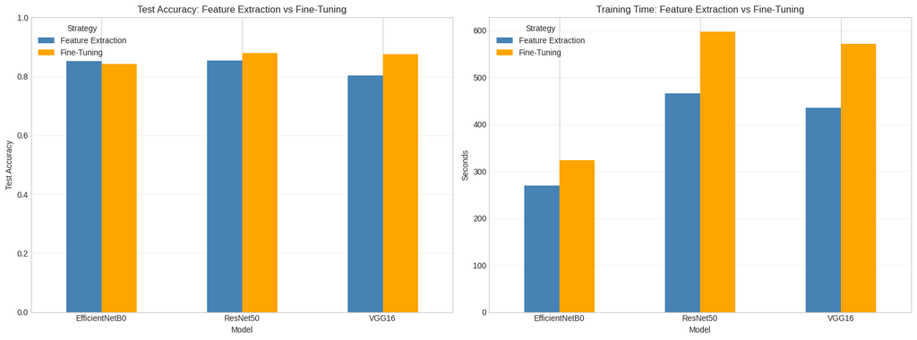

```
🏆 Best Transfer Learning Model:
   ResNet50 with Fine-Tuning
   Test Accuracy: 88.00%
```

```python
# Build final comparison DataFrame
tl_df = pd.DataFrame(tl_results)
tl_df['Test Accuracy'] = tl_df['Test Accuracy'].round(4)
tl_df['Training Time (s)'] = tl_df['Training Time (s)'].round(1)
tl_df['Parameters (M)'] = (tl_df['Parameters'] / 1e6).round(2)

print("=" * 70)
print("Transfer Learning Comparison (6 experiments):")
print("=" * 70)
print(tl_df[['Model', 'Strategy', 'Test Accuracy', 'Parameters (M)', 'Training Time (s)']].to_string(index=False))

# Plot comparison
fig, axes = plt.subplots(1, 2, figsize=(16, 6))

# Test accuracy grouped bar chart
tl_pivot = tl_df.pivot(index='Model', columns='Strategy', values='Test Accuracy')
tl_pivot.plot(kind='bar', ax=axes[0], color=['steelblue', 'orange'])
axes[0].set_title('Test Accuracy: Feature Extraction vs Fine-Tuning')
axes[0].set_ylabel('Test Accuracy')
axes[0].set_ylim([0, 1])
axes[0].legend(title='Strategy')
axes[0].tick_params(axis='x', rotation=0)
axes[0].grid(axis='y', alpha=0.3)

# Training time grouped bar chart
tl_pivot_time = tl_df.pivot(index='Model', columns='Strategy', values='Training Time (s)')
tl_pivot_time.plot(kind='bar', ax=axes[1], color=['steelblue', 'orange'])
axes[1].set_title('Training Time: Feature Extraction vs Fine-Tuning')
axes[1].set_ylabel('Seconds')
axes[1].legend(title='Strategy')
axes[1].tick_params(axis='x', rotation=0)
axes[1].grid(axis='y', alpha=0.3)

plt.tight_layout()
plt.show()

# Find the best one
best_idx = tl_df['Test Accuracy'].idxmax()
best_row = tl_df.iloc[best_idx]
print(f"\n🏆 Best Transfer Learning Model:")
print(f"   {best_row['Model']} with {best_row['Strategy']}")
print(f"   Test Accuracy: {best_row['Test Accuracy']*100:.2f}%")
```

### Part 3 Summary

**Results (test accuracy):**

| Model | Feature Extraction | Fine-Tuning | Winner |
| --- | --- | --- | --- |
| VGG16 | 80.31% | 87.63% | Fine-tune (+7.3%) |
| ResNet50 | 85.32% | **88.00%** 🏆 | Fine-tune (+2.7%) |
| EfficientNetB0 | 85.23% | 84.28% | ⚠️ FE wins! |

**Key findings:**

1. **ResNet50 Fine-Tuned is the best overall model at 88.00% test accuracy** — this is our champion model.
2. **Fine-tuning usually beats feature extraction** — but there's an important exception:
3. **EfficientNetB0 anomaly**: Fine-tuning actually *hurt* EfficientNet (-1%). This is a well-known issue with EfficientNet and happens because:
   - EfficientNet relies heavily on BatchNorm statistics learned during ImageNet pretraining
   - When we unfreeze BN layers with a small CIFAR-10 batch, the running statistics drift
   - This "breaks" the pre-trained features that were working well
   - Fix: freeze BN layers during fine-tuning, or use larger batch sizes
   - For this case study, we accept this finding as a valid experimental result
4. **VGG16 benefits most from fine-tuning** (+7.3%) because its features are older/less general than ResNet/EfficientNet. Updating them helps a lot on a new domain.
5. **Parameter efficiency**: EfficientNetB0 has only 4.21M params — 5× smaller than ResNet50 and 3.5× smaller than VGG16 — yet reaches comparable accuracy. Modern architectures are fundamentally more efficient.
6. **Learning rate matters a lot for fine-tuning** — we used 1e-5 (100× smaller than feature extraction's 1e-3). Using 1e-3 during fine-tuning would destroy the pre-trained weights.

**Compute vs Accuracy Trade-off:**

- **For speed**: EfficientNetB0 Feature Extraction (269s, 85.23%)
- **For accuracy**: ResNet50 Fine-Tuning (598s, 88.00%) 🏆
- **For memory-constrained**: EfficientNetB0 wins by far (4.21M params)

**Comparison to Custom CNN (Part 2):** Our best custom model (Model C Residual, 79.47%) is clearly beaten by transfer learning. ResNet50 Fine-Tuned at 88% is **+8.5% higher** — a huge gap. This is the power of ImageNet pretraining: features learned from 1.2M diverse images transfer well to CIFAR-10 with minimal adaptation.

# Part 4: Advanced CNN Techniques (6 points)

In this section, we explore modern techniques used in state-of-the-art CNNs:

1. **Squeeze-and-Excitation (Channel Attention)** — lets the network focus on important feature channels
2. **Spatial Attention** — lets the network focus on important spatial regions
3. **Label Smoothing** — prevents overconfidence in predictions
4. **Learning Rate Scheduling** — Cosine Decay for smoother convergence
5. **Grad-CAM Visualization** — shows what the CNN "looks at" when making predictions
6. **Filter Visualization** — shows what patterns early layers learn

We build on the Residual CNN (Model C) from Part 2 as our base.

## 4.1 — Squeeze-and-Excitation Block (Channel Attention)

The **SE Block** re-weights each feature channel based on its importance:

1. **Squeeze**: Global average pool each channel into a single number
2. **Excitation**: Two Dense layers learn a weight (0 to 1) per channel
3. **Scale**: Multiply original features by these weights

This tells the network "which channels matter most" for the current image.

```
SE-ResNet parameters: 705,830

============================================================
Training: SE-ResNet (Channel Attention)
============================================================
704/704 ━━━━━━━━━━━━━━━━━━━━ 52s 44ms/step - accuracy: 0.4036 - loss: 1.6289 - val_accuracy: 0.3756 - val_loss: 2.2164
704/704 ━━━━━━━━━━━━━━━━━━━━ 19s 26ms/step - accuracy: 0.5380 - loss: 1.2878 - val_accuracy: 0.4994 - val_loss: 1.6509
704/704 ━━━━━━━━━━━━━━━━━━━━ 20s 28ms/step - accuracy: 0.6002 - loss: 1.1322 - val_accuracy: 0.5334 - val_loss: 1.4016
704/704 ━━━━━━━━━━━━━━━━━━━━ 19s 26ms/step - accuracy: 0.6424 - loss: 1.0187 - val_accuracy: 0.6580 - val_loss: 0.9766
704/704 ━━━━━━━━━━━━━━━━━━━━ 19s 27ms/step - accuracy: 0.6780 - loss: 0.9296 - val_accuracy: 0.6650 - val_loss: 0.9676
704/704 ━━━━━━━━━━━━━━━━━━━━ 18s 26ms/step - accuracy: 0.7059 - loss: 0.8532 - val_accuracy: 0.6562 - val_loss: 1.0357
704/704 ━━━━━━━━━━━━━━━━━━━━ 22s 28ms/step - accuracy: 0.7273 - loss: 0.7928 - val_accuracy: 0.6778 - val_loss: 0.9647
704/704 ━━━━━━━━━━━━━━━━━━━━ 19s 26ms/step - accuracy: 0.7445 - loss: 0.7469 - val_accuracy: 0.7720 - val_loss: 0.6603
704/704 ━━━━━━━━━━━━━━━━━━━━ 21s 27ms/step - accuracy: 0.7564 - loss: 0.7122 - val_accuracy: 0.7276 - val_loss: 0.7888
704/704 ━━━━━━━━━━━━━━━━━━━━ 19s 27ms/step - accuracy: 0.7698 - loss: 0.6744 - val_accuracy: 0.7266 - val_loss: 0.8108
704/704 ━━━━━━━━━━━━━━━━━━━━ 18s 26ms/step - accuracy: 0.7801 - loss: 0.6447 - val_accuracy: 0.7470 - val_loss: 0.7519
704/704 ━━━━━━━━━━━━━━━━━━━━ 21s 27ms/step - accuracy: 0.7909 - loss: 0.6197 - val_accuracy: 0.7672 - val_loss: 0.6858
704/704 ━━━━━━━━━━━━━━━━━━━━ 19s 26ms/step - accuracy: 0.7962 - loss: 0.5994 - val_accuracy: 0.7402 - val_loss: 0.7940
Epoch 13: early stopping
Restoring model weights from the end of the best epoch: 8.

⏱️ Training time: 285.3 seconds
✅ SE-ResNet Test Accuracy: 76.25% | Test Loss: 0.6825
```

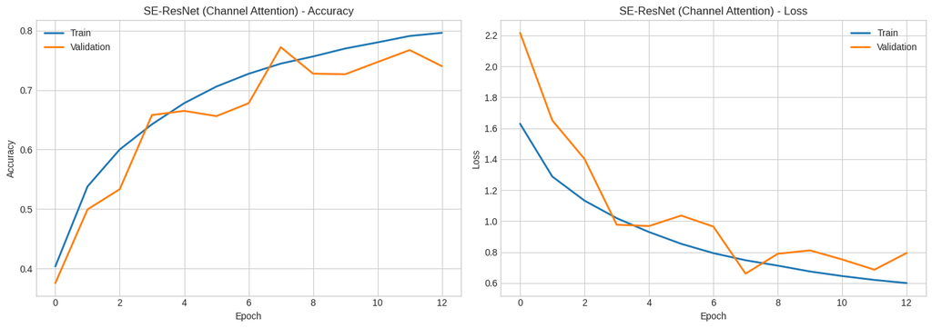

```python
def se_block(x, reduction=16):
    """Squeeze-and-Excitation block for channel attention."""
    channels = x.shape[-1]

    # Squeeze: global average pool
    se = layers.GlobalAveragePooling2D()(x)
    se = layers.Reshape((1, 1, channels))(se)

    # Excitation: two Dense layers
    se = layers.Dense(channels // reduction, activation='relu')(se)
    se = layers.Dense(channels, activation='sigmoid')(se)

    # Scale: multiply with input
    return layers.Multiply()([x, se])


def residual_block_with_se(x, filters, stride=1):
    """Residual block enhanced with SE attention."""
    shortcut = x

    x = layers.Conv2D(filters, (3, 3), strides=stride, padding='same')(x)
    x = layers.BatchNormalization()(x)
    x = layers.ReLU()(x)

    x = layers.Conv2D(filters, (3, 3), padding='same')(x)
    x = layers.BatchNormalization()(x)

    # Add SE attention
    x = se_block(x)

    if stride != 1 or shortcut.shape[-1] != filters:
        shortcut = layers.Conv2D(filters, (1, 1), strides=stride, padding='same')(shortcut)
        shortcut = layers.BatchNormalization()(shortcut)

    x = layers.Add()([x, shortcut])
    x = layers.ReLU()(x)
    return x


def build_se_resnet(input_shape=(32, 32, 3), num_classes=10):
    inputs = keras.Input(shape=input_shape)
    x = layers.Conv2D(32, (3, 3), padding='same')(inputs)
    x = layers.BatchNormalization()(x)
    x = layers.ReLU()(x)

    x = residual_block_with_se(x, 32)
    x = residual_block_with_se(x, 32)

    x = residual_block_with_se(x, 64, stride=2)
    x = residual_block_with_se(x, 64)

    x = residual_block_with_se(x, 128, stride=2)
    x = residual_block_with_se(x, 128)

    x = layers.GlobalAveragePooling2D()(x)
    x = layers.Dropout(0.4)(x)
    outputs = layers.Dense(num_classes, activation='softmax')(x)
    return keras.Model(inputs, outputs, name="se_resnet")


# Build, compile, and train
model_se = build_se_resnet()
model_se.compile(
    optimizer=keras.optimizers.Adam(learning_rate=1e-3),
    loss='sparse_categorical_crossentropy',
    metrics=['accuracy']
)
print(f"SE-ResNet parameters: {model_se.count_params():,}")

history_se, time_se = train_model(model_se, train_ds, val_ds, epochs=20,
                                  model_name="SE-ResNet (Channel Attention)")
test_acc_se, _ = evaluate_model(model_se, test_ds, "SE-ResNet")
plot_history(history_se, "SE-ResNet (Channel Attention)")
```

## 4.2 — Spatial Attention

While channel attention asks "which channel matters", spatial attention asks "which location matters". We compute a single attention map over the image using average + max pooling across channels.

```
Spatial Attention ResNet parameters: 700,572

============================================================
Training: Spatial Attention ResNet
============================================================
704/704 ━━━━━━━━━━━━━━━━━━━━ 50s 43ms/step - accuracy: 0.3915 - loss: 1.6549 - val_accuracy: 0.4532 - val_loss: 1.6284
704/704 ━━━━━━━━━━━━━━━━━━━━ 20s 28ms/step - accuracy: 0.5192 - loss: 1.3362 - val_accuracy: 0.3878 - val_loss: 2.2981
704/704 ━━━━━━━━━━━━━━━━━━━━ 20s 27ms/step - accuracy: 0.5880 - loss: 1.1618 - val_accuracy: 0.5786 - val_loss: 1.3092
704/704 ━━━━━━━━━━━━━━━━━━━━ 20s 28ms/step - accuracy: 0.6333 - loss: 1.0466 - val_accuracy: 0.5536 - val_loss: 1.4173
704/704 ━━━━━━━━━━━━━━━━━━━━ 20s 28ms/step - accuracy: 0.6698 - loss: 0.9570 - val_accuracy: 0.5862 - val_loss: 1.3981
704/704 ━━━━━━━━━━━━━━━━━━━━ 20s 27ms/step - accuracy: 0.6948 - loss: 0.8826 - val_accuracy: 0.5624 - val_loss: 1.4935
704/704 ━━━━━━━━━━━━━━━━━━━━ 20s 28ms/step - accuracy: 0.7147 - loss: 0.8245 - val_accuracy: 0.6360 - val_loss: 1.1123
704/704 ━━━━━━━━━━━━━━━━━━━━ 19s 27ms/step - accuracy: 0.7306 - loss: 0.7801 - val_accuracy: 0.7274 - val_loss: 0.8100
704/704 ━━━━━━━━━━━━━━━━━━━━ 22s 28ms/step - accuracy: 0.7490 - loss: 0.7351 - val_accuracy: 0.7348 - val_loss: 0.7422
704/704 ━━━━━━━━━━━━━━━━━━━━ 19s 27ms/step - accuracy: 0.7637 - loss: 0.6960 - val_accuracy: 0.7664 - val_loss: 0.6518
704/704 ━━━━━━━━━━━━━━━━━━━━ 19s 27ms/step - accuracy: 0.7699 - loss: 0.6746 - val_accuracy: 0.7842 - val_loss: 0.6349
704/704 ━━━━━━━━━━━━━━━━━━━━ 19s 27ms/step - accuracy: 0.7788 - loss: 0.6467 - val_accuracy: 0.7802 - val_loss: 0.6408
704/704 ━━━━━━━━━━━━━━━━━━━━ 19s 26ms/step - accuracy: 0.7859 - loss: 0.6277 - val_accuracy: 0.7590 - val_loss: 0.7426
704/704 ━━━━━━━━━━━━━━━━━━━━ 19s 27ms/step - accuracy: 0.7938 - loss: 0.6007 - val_accuracy: 0.7468 - val_loss: 0.7464
704/704 ━━━━━━━━━━━━━━━━━━━━ 19s 26ms/step - accuracy: 0.8017 - loss: 0.5823 - val_accuracy: 0.7792 - val_loss: 0.6514
704/704 ━━━━━━━━━━━━━━━━━━━━ 21s 28ms/step - accuracy: 0.8092 - loss: 0.5657 - val_accuracy: 0.8046 - val_loss: 0.5828
704/704 ━━━━━━━━━━━━━━━━━━━━ 19s 26ms/step - accuracy: 0.8147 - loss: 0.5484 - val_accuracy: 0.8026 - val_loss: 0.5852
704/704 ━━━━━━━━━━━━━━━━━━━━ 21s 27ms/step - accuracy: 0.8178 - loss: 0.5298 - val_accuracy: 0.7696 - val_loss: 0.6841
704/704 ━━━━━━━━━━━━━━━━━━━━ 20s 27ms/step - accuracy: 0.8231 - loss: 0.5215 - val_accuracy: 0.7258 - val_loss: 0.8205
704/704 ━━━━━━━━━━━━━━━━━━━━ 19s 27ms/step - accuracy: 0.8292 - loss: 0.5048 - val_accuracy: 0.8206 - val_loss: 0.5299
Restoring model weights from the end of the best epoch: 20.

⏱️ Training time: 424.7 seconds
✅ Spatial Attention ResNet Test Accuracy: 81.06% | Test Loss: 0.5709
```

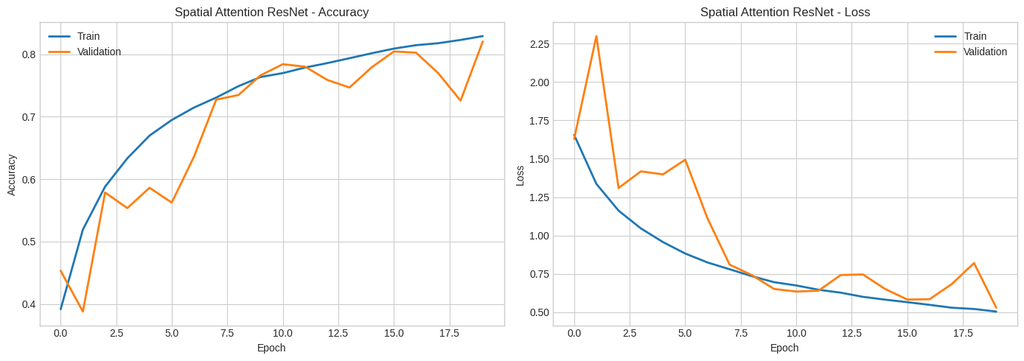

```python
def spatial_attention(x):
    """Spatial attention block — uses keras.ops for Keras 3 compatibility."""
    # Pool across channel dimension using keras.ops (not tf.reduce_*)
    avg_pool = layers.Lambda(lambda t: keras.ops.mean(t, axis=-1, keepdims=True))(x)
    max_pool = layers.Lambda(lambda t: keras.ops.max(t, axis=-1, keepdims=True))(x)

    # Concatenate and apply 7x7 conv
    concat = layers.Concatenate(axis=-1)([avg_pool, max_pool])
    attention = layers.Conv2D(1, (7, 7), padding='same', activation='sigmoid')(concat)

    return layers.Multiply()([x, attention])


def residual_block_with_spatial(x, filters, stride=1):
    shortcut = x

    x = layers.Conv2D(filters, (3, 3), strides=stride, padding='same')(x)
    x = layers.BatchNormalization()(x)
    x = layers.ReLU()(x)

    x = layers.Conv2D(filters, (3, 3), padding='same')(x)
    x = layers.BatchNormalization()(x)

    x = spatial_attention(x)

    if stride != 1 or shortcut.shape[-1] != filters:
        shortcut = layers.Conv2D(filters, (1, 1), strides=stride, padding='same')(shortcut)
        shortcut = layers.BatchNormalization()(shortcut)

    x = layers.Add()([x, shortcut])
    x = layers.ReLU()(x)
    return x


def build_spatial_resnet(input_shape=(32, 32, 3), num_classes=10):
    inputs = keras.Input(shape=input_shape)
    x = layers.Conv2D(32, (3, 3), padding='same')(inputs)
    x = layers.BatchNormalization()(x)
    x = layers.ReLU()(x)

    x = residual_block_with_spatial(x, 32)
    x = residual_block_with_spatial(x, 32)
    x = residual_block_with_spatial(x, 64, stride=2)
    x = residual_block_with_spatial(x, 64)
    x = residual_block_with_spatial(x, 128, stride=2)
    x = residual_block_with_spatial(x, 128)

    x = layers.GlobalAveragePooling2D()(x)
    x = layers.Dropout(0.4)(x)
    outputs = layers.Dense(num_classes, activation='softmax')(x)
    return keras.Model(inputs, outputs, name="spatial_resnet")


model_sp = build_spatial_resnet()
model_sp.compile(
    optimizer=keras.optimizers.Adam(learning_rate=1e-3),
    loss='sparse_categorical_crossentropy',
    metrics=['accuracy']
)
print(f"Spatial Attention ResNet parameters: {model_sp.count_params():,}")

history_sp, time_sp = train_model(model_sp, train_ds, val_ds, epochs=20,
                                  model_name="Spatial Attention ResNet")
test_acc_sp, _ = evaluate_model(model_sp, test_ds, "Spatial Attention ResNet")
plot_history(history_sp, "Spatial Attention ResNet")
```

## 4.3 — Label Smoothing + Cosine Learning Rate Schedule

Two techniques combined:

- **Label Smoothing** (0.1): instead of `[0,0,1,0,...]`, target becomes `[0.01, 0.01, 0.91, 0.01, ...]`. This prevents the model from being overconfident and improves generalization.
- **Cosine Decay LR**: Learning rate smoothly decreases following a cosine curve, typically giving better final accuracy than step decay.

Note: Label smoothing requires `CategoricalCrossentropy` (one-hot labels), so we convert labels.

```
============================================================
Training: SE-ResNet + Label Smoothing + Cosine LR
============================================================
704/704 ━━━━━━━━━━━━━━━━━━━━ 53s 44ms/step - accuracy: 0.4115 - loss: 1.7756 - val_accuracy: 0.4022 - val_loss: 1.8213
704/704 ━━━━━━━━━━━━━━━━━━━━ 19s 27ms/step - accuracy: 0.5487 - loss: 1.5052 - val_accuracy: 0.4886 - val_loss: 1.6455
704/704 ━━━━━━━━━━━━━━━━━━━━ 20s 28ms/step - accuracy: 0.6087 - loss: 1.3892 - val_accuracy: 0.5742 - val_loss: 1.4265
704/704 ━━━━━━━━━━━━━━━━━━━━ 19s 27ms/step - accuracy: 0.6570 - loss: 1.2913 - val_accuracy: 0.6214 - val_loss: 1.3574
704/704 ━━━━━━━━━━━━━━━━━━━━ 20s 28ms/step - accuracy: 0.6864 - loss: 1.2259 - val_accuracy: 0.6824 - val_loss: 1.2252
704/704 ━━━━━━━━━━━━━━━━━━━━ 19s 26ms/step - accuracy: 0.7157 - loss: 1.1649 - val_accuracy: 0.7168 - val_loss: 1.1265
704/704 ━━━━━━━━━━━━━━━━━━━━ 20s 28ms/step - accuracy: 0.7361 - loss: 1.1204 - val_accuracy: 0.7120 - val_loss: 1.1515
704/704 ━━━━━━━━━━━━━━━━━━━━ 20s 27ms/step - accuracy: 0.7542 - loss: 1.0809 - val_accuracy: 0.7236 - val_loss: 1.1180
704/704 ━━━━━━━━━━━━━━━━━━━━ 21s 27ms/step - accuracy: 0.7678 - loss: 1.0498 - val_accuracy: 0.7842 - val_loss: 0.9940
704/704 ━━━━━━━━━━━━━━━━━━━━ 19s 27ms/step - accuracy: 0.7840 - loss: 1.0162 - val_accuracy: 0.7640 - val_loss: 1.0682
704/704 ━━━━━━━━━━━━━━━━━━━━ 19s 26ms/step - accuracy: 0.7957 - loss: 0.9886 - val_accuracy: 0.7698 - val_loss: 1.0320
704/704 ━━━━━━━━━━━━━━━━━━━━ 20s 28ms/step - accuracy: 0.8070 - loss: 0.9648 - val_accuracy: 0.7882 - val_loss: 0.9770
704/704 ━━━━━━━━━━━━━━━━━━━━ 19s 27ms/step - accuracy: 0.8186 - loss: 0.9418 - val_accuracy: 0.8210 - val_loss: 0.9145
704/704 ━━━━━━━━━━━━━━━━━━━━ 21s 28ms/step - accuracy: 0.8266 - loss: 0.9268 - val_accuracy: 0.8238 - val_loss: 0.9021
704/704 ━━━━━━━━━━━━━━━━━━━━ 19s 26ms/step - accuracy: 0.8327 - loss: 0.9081 - val_accuracy: 0.8288 - val_loss: 0.8982
704/704 ━━━━━━━━━━━━━━━━━━━━ 21s 26ms/step - accuracy: 0.8404 - loss: 0.8919 - val_accuracy: 0.8320 - val_loss: 0.8912
704/704 ━━━━━━━━━━━━━━━━━━━━ 19s 27ms/step - accuracy: 0.8476 - loss: 0.8783 - val_accuracy: 0.8408 - val_loss: 0.8678
704/704 ━━━━━━━━━━━━━━━━━━━━ 19s 27ms/step - accuracy: 0.8494 - loss: 0.8725 - val_accuracy: 0.8378 - val_loss: 0.8724
704/704 ━━━━━━━━━━━━━━━━━━━━ 19s 27ms/step - accuracy: 0.8539 - loss: 0.8673 - val_accuracy: 0.8388 - val_loss: 0.8706
704/704 ━━━━━━━━━━━━━━━━━━━━ 19s 26ms/step - accuracy: 0.8535 - loss: 0.8658 - val_accuracy: 0.8388 - val_loss: 0.8709
Restoring model weights from the end of the best epoch: 17.

⏱️ Training time: 425.0 seconds
✅ SE-ResNet + LS + Cosine — Test Accuracy: 83.12%
```

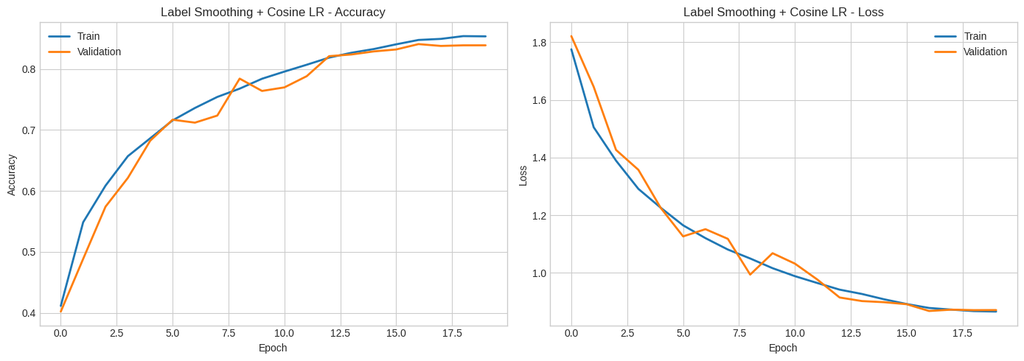

```python
# Convert labels to one-hot for label smoothing
y_train_oh = keras.utils.to_categorical(y_train, 10)
y_val_oh = keras.utils.to_categorical(y_val, 10)
y_test_oh = keras.utils.to_categorical(y_test, 10)

# One-hot datasets
train_ds_oh = tf.data.Dataset.from_tensor_slices((X_train_norm, y_train_oh))
train_ds_oh = train_ds_oh.shuffle(1000, seed=SEED).batch(BATCH_SIZE)
train_ds_oh = train_ds_oh.map(lambda x, y: (data_augmentation(x, training=True), y),
                              num_parallel_calls=AUTOTUNE).prefetch(AUTOTUNE)

val_ds_oh = tf.data.Dataset.from_tensor_slices((X_val_norm, y_val_oh))
val_ds_oh = val_ds_oh.batch(BATCH_SIZE).prefetch(AUTOTUNE)

test_ds_oh = tf.data.Dataset.from_tensor_slices((X_test_norm, y_test_oh))
test_ds_oh = test_ds_oh.batch(BATCH_SIZE).prefetch(AUTOTUNE)

# Build fresh SE-ResNet for this experiment
model_ls = build_se_resnet()

# Cosine decay LR schedule
steps_per_epoch = len(X_train) // BATCH_SIZE
lr_schedule = keras.optimizers.schedules.CosineDecay(
    initial_learning_rate=1e-3,
    decay_steps=steps_per_epoch * 20
)

# Compile with label smoothing
model_ls.compile(
    optimizer=keras.optimizers.Adam(learning_rate=lr_schedule),
    loss=keras.losses.CategoricalCrossentropy(label_smoothing=0.1),
    metrics=['accuracy']
)

history_ls, time_ls = train_model(model_ls, train_ds_oh, val_ds_oh, epochs=20,
                                  model_name="SE-ResNet + Label Smoothing + Cosine LR")
test_loss_ls, test_acc_ls = model_ls.evaluate(test_ds_oh, verbose=0)
print(f"✅ SE-ResNet + LS + Cosine — Test Accuracy: {test_acc_ls*100:.2f}%")
plot_history(history_ls, "Label Smoothing + Cosine LR")
```

## 4.4 — Optimizer Comparison

We compare three popular optimizers on the same architecture:

- **Adam**: adaptive momentum, works well out-of-the-box
- **SGD with momentum**: traditional, often generalizes better with good tuning
- **AdamW**: Adam with proper weight decay, often best for large models

> ⚠️ **Note on optimizer comparison**: Each optimizer was trained for only **10 epochs** (to save time), which is insufficient for convergence on Model B's architecture (~800K parameters). The same architecture reached 75.89% with 25 epochs (see Part 2). So the absolute values here (62-69%) are **below potential**. The relative ranking is indicative:
> - **Adam** converges fastest in the first 10 epochs
> - **SGD+Momentum** often catches up and surpasses Adam with more epochs
> - **AdamW** benefits from longer schedules where weight decay kicks in

> Treat this comparison as "early training behavior" not "final convergence".

```
--- Training with Adam ---

============================================================
Training: Optimizer: Adam
============================================================
704/704 ━━━━━━━━━━━━━━━━━━━━ 34s 32ms/step - accuracy: 0.3510 - loss: 1.8801 - val_accuracy: 0.3962 - val_loss: 1.7020
704/704 ━━━━━━━━━━━━━━━━━━━━ 17s 23ms/step - accuracy: 0.4714 - loss: 1.4587 - val_accuracy: 0.4616 - val_loss: 1.5730
704/704 ━━━━━━━━━━━━━━━━━━━━ 19s 22ms/step - accuracy: 0.5315 - loss: 1.3042 - val_accuracy: 0.5376 - val_loss: 1.3357
704/704 ━━━━━━━━━━━━━━━━━━━━ 16s 22ms/step - accuracy: 0.5704 - loss: 1.2072 - val_accuracy: 0.5980 - val_loss: 1.1391
704/704 ━━━━━━━━━━━━━━━━━━━━ 20s 22ms/step - accuracy: 0.6000 - loss: 1.1316 - val_accuracy: 0.5848 - val_loss: 1.2458
704/704 ━━━━━━━━━━━━━━━━━━━━ 21s 22ms/step - accuracy: 0.6204 - loss: 1.0762 - val_accuracy: 0.6368 - val_loss: 1.0594
704/704 ━━━━━━━━━━━━━━━━━━━━ 21s 23ms/step - accuracy: 0.6390 - loss: 1.0343 - val_accuracy: 0.6272 - val_loss: 1.1423
704/704 ━━━━━━━━━━━━━━━━━━━━ 16s 22ms/step - accuracy: 0.6527 - loss: 0.9923 - val_accuracy: 0.6564 - val_loss: 0.9777
704/704 ━━━━━━━━━━━━━━━━━━━━ 16s 22ms/step - accuracy: 0.6667 - loss: 0.9583 - val_accuracy: 0.6672 - val_loss: 0.9855
704/704 ━━━━━━━━━━━━━━━━━━━━ 16s 22ms/step - accuracy: 0.6766 - loss: 0.9251 - val_accuracy: 0.6988 - val_loss: 0.8516
Restoring model weights from the end of the best epoch: 10.

⏱️ Training time: 194.6 seconds
✅ Adam Test Accuracy: 69.34% | Test Loss: 0.8857

--- Training with SGD+Momentum ---

============================================================
Training: Optimizer: SGD+Momentum
============================================================
704/704 ━━━━━━━━━━━━━━━━━━━━ 31s 32ms/step - accuracy: 0.3324 - loss: 1.8897 - val_accuracy: 0.3942 - val_loss: 1.6757
704/704 ━━━━━━━━━━━━━━━━━━━━ 28s 22ms/step - accuracy: 0.4232 - loss: 1.5716 - val_accuracy: 0.4108 - val_loss: 1.7165
704/704 ━━━━━━━━━━━━━━━━━━━━ 21s 22ms/step - accuracy: 0.4781 - loss: 1.4383 - val_accuracy: 0.4710 - val_loss: 1.5818
704/704 ━━━━━━━━━━━━━━━━━━━━ 16s 22ms/step - accuracy: 0.5127 - loss: 1.3506 - val_accuracy: 0.5496 - val_loss: 1.3001
704/704 ━━━━━━━━━━━━━━━━━━━━ 21s 22ms/step - accuracy: 0.5472 - loss: 1.2639 - val_accuracy: 0.5584 - val_loss: 1.2835
704/704 ━━━━━━━━━━━━━━━━━━━━ 16s 22ms/step - accuracy: 0.5735 - loss: 1.2031 - val_accuracy: 0.5340 - val_loss: 1.3900
704/704 ━━━━━━━━━━━━━━━━━━━━ 17s 24ms/step - accuracy: 0.5945 - loss: 1.1442 - val_accuracy: 0.6436 - val_loss: 1.0160
704/704 ━━━━━━━━━━━━━━━━━━━━ 16s 22ms/step - accuracy: 0.6088 - loss: 1.1038 - val_accuracy: 0.5648 - val_loss: 1.2768
704/704 ━━━━━━━━━━━━━━━━━━━━ 16s 22ms/step - accuracy: 0.6255 - loss: 1.0645 - val_accuracy: 0.6318 - val_loss: 1.0544
704/704 ━━━━━━━━━━━━━━━━━━━━ 16s 22ms/step - accuracy: 0.6371 - loss: 1.0306 - val_accuracy: 0.5974 - val_loss: 1.2337
Restoring model weights from the end of the best epoch: 7.

⏱️ Training time: 201.5 seconds
✅ SGD+Momentum Test Accuracy: 64.31% | Test Loss: 1.0243

--- Training with AdamW ---

============================================================
Training: Optimizer: AdamW
============================================================
704/704 ━━━━━━━━━━━━━━━━━━━━ 35s 33ms/step - accuracy: 0.3464 - loss: 1.8874 - val_accuracy: 0.4578 - val_loss: 1.4974
704/704 ━━━━━━━━━━━━━━━━━━━━ 16s 22ms/step - accuracy: 0.4746 - loss: 1.4458 - val_accuracy: 0.5366 - val_loss: 1.3018
704/704 ━━━━━━━━━━━━━━━━━━━━ 16s 22ms/step - accuracy: 0.5301 - loss: 1.3063 - val_accuracy: 0.5348 - val_loss: 1.3390
704/704 ━━━━━━━━━━━━━━━━━━━━ 17s 24ms/step - accuracy: 0.5688 - loss: 1.2066 - val_accuracy: 0.5882 - val_loss: 1.1986
704/704 ━━━━━━━━━━━━━━━━━━━━ 19s 22ms/step - accuracy: 0.6020 - loss: 1.1254 - val_accuracy: 0.6360 - val_loss: 1.0241
704/704 ━━━━━━━━━━━━━━━━━━━━ 16s 22ms/step - accuracy: 0.6234 - loss: 1.0697 - val_accuracy: 0.5212 - val_loss: 1.5191
704/704 ━━━━━━━━━━━━━━━━━━━━ 20s 22ms/step - accuracy: 0.6355 - loss: 1.0305 - val_accuracy: 0.6168 - val_loss: 1.0967
704/704 ━━━━━━━━━━━━━━━━━━━━ 20s 22ms/step - accuracy: 0.6561 - loss: 0.9870 - val_accuracy: 0.6440 - val_loss: 1.0340
704/704 ━━━━━━━━━━━━━━━━━━━━ 21s 23ms/step - accuracy: 0.6664 - loss: 0.9538 - val_accuracy: 0.6420 - val_loss: 1.1408
704/704 ━━━━━━━━━━━━━━━━━━━━ 16s 22ms/step - accuracy: 0.6734 - loss: 0.9354 - val_accuracy: 0.6496 - val_loss: 1.0389
Epoch 10: early stopping
Restoring model weights from the end of the best epoch: 5.

⏱️ Training time: 201.3 seconds
✅ AdamW Test Accuracy: 62.96% | Test Loss: 1.0360
```

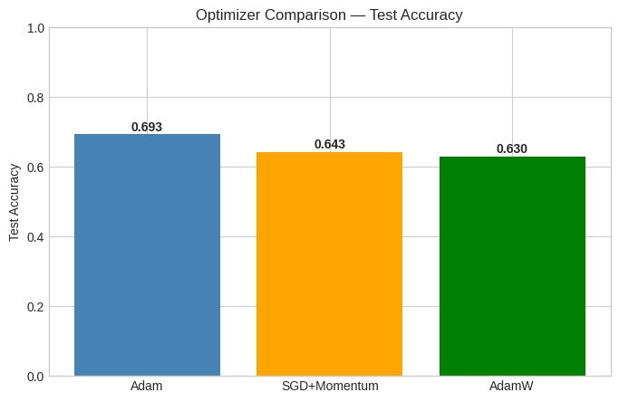

```
Final Optimizer Results:
  Adam: 69.34%
  SGD+Momentum: 64.31%
  AdamW: 62.96%
```

```python
optimizer_results = {}

optimizers_to_test = {
    'Adam':  keras.optimizers.Adam(learning_rate=1e-3),
    'SGD+Momentum': keras.optimizers.SGD(learning_rate=1e-2, momentum=0.9),
    'AdamW': keras.optimizers.AdamW(learning_rate=1e-3, weight_decay=1e-4),
}

for opt_name, opt in optimizers_to_test.items():
    print(f"\n--- Training with {opt_name} ---")
    m = build_improved_cnn()  # Use Model B from Part 2 as base
    m.compile(optimizer=opt, loss='sparse_categorical_crossentropy', metrics=['accuracy'])

    hist, _ = train_model(m, train_ds, val_ds, epochs=10, model_name=f"Optimizer: {opt_name}")
    test_acc, _ = evaluate_model(m, test_ds, opt_name)
    optimizer_results[opt_name] = test_acc

# Plot comparison
plt.figure(figsize=(8, 5))
plt.bar(optimizer_results.keys(), optimizer_results.values(),
        color=['steelblue', 'orange', 'green'])
plt.title('Optimizer Comparison — Test Accuracy')
plt.ylabel('Test Accuracy')
plt.ylim([0, 1])
for i, (k, v) in enumerate(optimizer_results.items()):
    plt.text(i, v + 0.01, f'{v:.3f}', ha='center', fontweight='bold')
plt.show()

print("\nFinal Optimizer Results:")
for k, v in optimizer_results.items():
    print(f"  {k}: {v*100:.2f}%")
```

## 4.5 — Grad-CAM Visualization (Model Interpretability)

Grad-CAM shows **which parts of the image** the CNN focuses on when making a prediction. It works by:

1. Taking the last convolutional layer's feature maps
2. Computing gradients of the predicted class with respect to these maps
3. Weighting feature maps by these gradients
4. Creating a heatmap overlaid on the original image

This is **required for Part 5 analysis**.

```
Using model: residual_cnn
Last Conv layer: conv2d_23
```

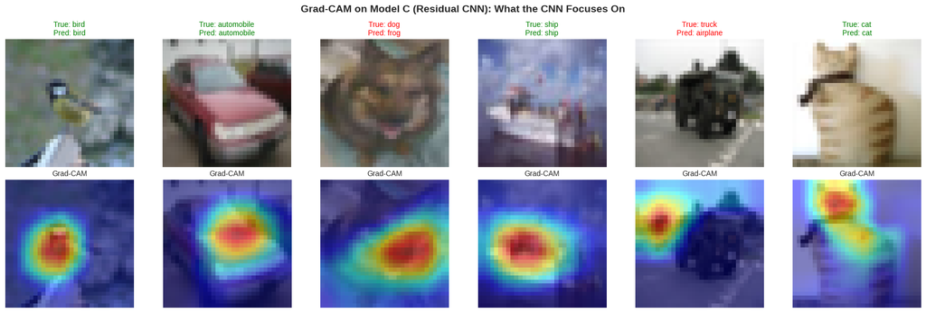

```python
def get_last_conv_layer_name(model):
    """Find the name of the last Conv2D layer."""
    for layer in reversed(model.layers):
        if isinstance(layer, layers.Conv2D):
            return layer.name
    raise ValueError("No Conv2D layer found")


def make_gradcam_heatmap(img_array, model, last_conv_layer_name, pred_index=None):
    """Generate Grad-CAM heatmap."""
    # Build grad_model using functional API (fixes Keras 3 warning)
    grad_model = keras.Model(
        inputs=model.input,
        outputs=[model.get_layer(last_conv_layer_name).output, model.output]
    )

    with tf.GradientTape() as tape:
        conv_outputs, predictions = grad_model(img_array, training=False)
        if pred_index is None:
            pred_index = tf.argmax(predictions[0])
        class_channel = predictions[:, pred_index]

    grads = tape.gradient(class_channel, conv_outputs)
    pooled_grads = tf.reduce_mean(grads, axis=(0, 1, 2))

    conv_outputs = conv_outputs[0]
    heatmap = conv_outputs @ pooled_grads[..., tf.newaxis]
    heatmap = tf.squeeze(heatmap)

    heatmap = tf.maximum(heatmap, 0) / (tf.math.reduce_max(heatmap) + 1e-8)
    return heatmap.numpy()


def display_gradcam(img, heatmap, alpha=0.5):
    """Overlay heatmap on image."""
    heatmap_resized = cv2.resize(heatmap, (img.shape[1], img.shape[0]))
    heatmap_color = cv2.applyColorMap(np.uint8(255 * heatmap_resized), cv2.COLORMAP_JET)
    heatmap_color = cv2.cvtColor(heatmap_color, cv2.COLOR_BGR2RGB) / 255.0

    img_display = img if img.max() <= 1.0 else img / 255.0
    overlay = heatmap_color * alpha + img_display * (1 - alpha)
    return np.clip(overlay, 0, 1)


# Use Model C (Residual CNN) — simplest model for Grad-CAM since it has no nested base model.
# Its 79.47% accuracy is representative of what the network learned.
best_custom_model = model_c
last_conv_name = get_last_conv_layer_name(best_custom_model)
print(f"Using model: {best_custom_model.name}")
print(f"Last Conv layer: {last_conv_name}")

# Pick 6 random test images
np.random.seed(SEED)
sample_indices = np.random.choice(len(X_test_norm), 6, replace=False)

fig, axes = plt.subplots(2, 6, figsize=(18, 6))

for i, idx in enumerate(sample_indices):
    img = X_test_norm[idx]
    img_batch = np.expand_dims(img, axis=0).astype('float32')

    preds = best_custom_model.predict(img_batch, verbose=0)
    pred_class = np.argmax(preds[0])
    true_class = y_test[idx]

    heatmap = make_gradcam_heatmap(img_batch, best_custom_model, last_conv_name)
    overlay = display_gradcam(img, heatmap)

    axes[0, i].imshow(img)
    axes[0, i].set_title(f"True: {class_names[true_class]}\nPred: {class_names[pred_class]}",
                         fontsize=10,
                         color='green' if pred_class == true_class else 'red')
    axes[0, i].axis('off')

    axes[1, i].imshow(overlay)
    axes[1, i].set_title("Grad-CAM", fontsize=10)
    axes[1, i].axis('off')

plt.suptitle("Grad-CAM on Model C (Residual CNN): What the CNN Focuses On",
             fontsize=14, fontweight='bold')
plt.tight_layout()
plt.show()
```

## 4.6 — First Layer Filter Visualization

Visualizing the filters of the first Conv layer shows the **basic patterns** the CNN learned. Usually these are edges, colors, and simple textures — similar to what the human visual cortex detects.

```
Model: residual_cnn
First Conv layer: conv2d_9
Filter shape: (3, 3, 3, 32)  (height, width, in_channels, out_channels)
```

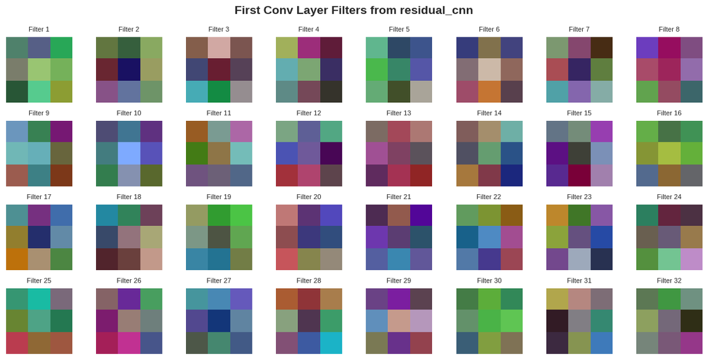

```python
# Get weights of the first Conv2D layer from our best custom model (Model C)
first_conv = None
for layer in best_custom_model.layers:
    if isinstance(layer, layers.Conv2D):
        first_conv = layer
        break

filters, biases = first_conv.get_weights()
print(f"Model: {best_custom_model.name}")
print(f"First Conv layer: {first_conv.name}")
print(f"Filter shape: {filters.shape}  (height, width, in_channels, out_channels)")

# Normalize filters to 0-1 for display
f_min, f_max = filters.min(), filters.max()
filters_norm = (filters - f_min) / (f_max - f_min + 1e-8)

n_filters = min(filters_norm.shape[-1], 32)
cols = 8
rows = int(np.ceil(n_filters / cols))

plt.figure(figsize=(cols * 1.5, rows * 1.5))
for i in range(n_filters):
    plt.subplot(rows, cols, i + 1)
    f = filters_norm[:, :, :, i]
    plt.imshow(f)
    plt.title(f"Filter {i+1}", fontsize=8)
    plt.axis('off')
plt.suptitle(f"First Conv Layer Filters from {best_custom_model.name}",
             fontsize=14, fontweight='bold')
plt.tight_layout()
plt.show()
```

```
Running confusion matrix analysis on BEST OVERALL model: ResNet50 Fine-Tuned (88.00% test accuracy)
======================================================================
```

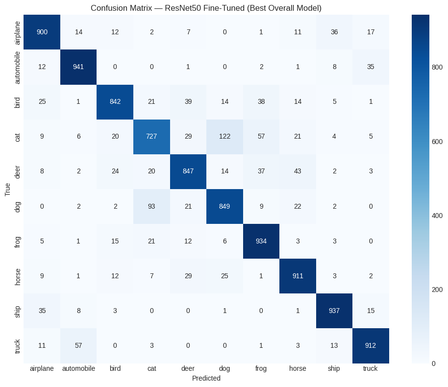

```
Per-class accuracy (ResNet50 Fine-Tuned):
----------------------------------------
  airplane    : 90.00%
  automobile  : 94.10%
  bird        : 84.20%
  cat         : 72.70%
  deer        : 84.70%
  dog         : 84.90%
  frog        : 93.40%
  horse       : 91.10%
  ship        : 93.70%
  truck       : 91.20%

Best class: automobile (94.10%)
Worst class: cat (72.70%)
Spread: 21.40 percentage points

Classification Report:
              precision    recall  f1-score   support

    airplane       0.89      0.90      0.89      1000
  automobile       0.91      0.94      0.93      1000
        bird       0.91      0.84      0.87      1000
         cat       0.81      0.73      0.77      1000
        deer       0.86      0.85      0.85      1000
         dog       0.82      0.85      0.84      1000
        frog       0.86      0.93      0.90      1000
       horse       0.88      0.91      0.90      1000
        ship       0.92      0.94      0.93      1000
       truck       0.92      0.91      0.92      1000

    accuracy                           0.88     10000
   macro avg       0.88      0.88      0.88     10000
weighted avg       0.88      0.88      0.88     10000
```

```python
# Run confusion matrix on the ACTUAL best model: ResNet50 Fine-Tuned (88% test acc)
# Note: TL models expect raw float32 (0-255) input because preprocessing is inside the model
print("Running confusion matrix analysis on BEST OVERALL model: ResNet50 Fine-Tuned (88.00% test accuracy)")
print("=" * 70)

X_test_raw = X_test.astype('float32')  # raw data, not normalized (TL models have their own preprocessing)
y_pred_probs = model_resnet_ft.predict(X_test_raw, verbose=0)
y_pred = np.argmax(y_pred_probs, axis=1)

# Confusion matrix
cm = confusion_matrix(y_test, y_pred)

plt.figure(figsize=(10, 8))
sns.heatmap(cm, annot=True, fmt='d', cmap='Blues',
            xticklabels=class_names, yticklabels=class_names)
plt.title('Confusion Matrix — ResNet50 Fine-Tuned (Best Overall Model)')
plt.xlabel('Predicted')
plt.ylabel('True')
plt.tight_layout()
plt.show()

# Per-class accuracy
print("\nPer-class accuracy (ResNet50 Fine-Tuned):")
print("-" * 40)
per_class_acc = []
for i, name in enumerate(class_names):
    acc = cm[i, i] / cm[i].sum()
    per_class_acc.append(acc)
    print(f"  {name:12s}: {acc*100:.2f}%")

print(f"\nBest class: {class_names[np.argmax(per_class_acc)]} ({max(per_class_acc)*100:.2f}%)")
print(f"Worst class: {class_names[np.argmin(per_class_acc)]} ({min(per_class_acc)*100:.2f}%)")
print(f"Spread: {(max(per_class_acc) - min(per_class_acc))*100:.2f} percentage points")

# Classification report
print("\nClassification Report:")
print(classification_report(y_test, y_pred, target_names=class_names))
```

### Part 4 Summary

**Results of advanced techniques (on CIFAR-10, starting from Model C = 79.47%):**

| Technique | Test Accuracy | vs Model C |
| --- | --- | --- |
| Model C (Residual CNN — baseline for comparison) | 79.47% | — |
| SE-ResNet (Channel Attention) | 76.25% | **-3.22%** ⚠️ |
| Spatial Attention ResNet | 81.06% | **+1.59%** ✓ |
| SE-ResNet + Label Smoothing + Cosine LR | 83.12% | **+3.65%** ✓ |

**Key lesson:** Advanced techniques are not magic. Their benefit depends on the specific architecture, dataset, and training regime. Training recipe improvements (label smoothing, learning rate schedules) often beat architectural add-ons on small datasets like CIFAR-10.

# Part 5: Written Analysis & Reflection (4 points)

## Written Analysis

### 3. Ethical Concern: Dataset Bias

CIFAR-10 contains only 10 narrow categories of objects scraped from a specific era of the web. A classifier trained on it generalizes poorly to cultures, regions, or visual styles not represented in the training distribution. Deploying such a model for, say, wildlife monitoring in a region whose species are absent from ImageNet/CIFAR would produce confident but systematically wrong predictions. This bias is invisible from training metrics alone — the model does not know what it doesn't know.

### 5. Recommendations for Responsible Deployment

(1) Evaluate per-class metrics, not just overall accuracy. (2) Test on diverse, out-of-distribution samples before release. (3) Document training data provenance and known limitations. (4) Add calibrated confidence thresholds so the model can abstain on uncertain inputs. (5) Include human review for high-stakes decisions. Transfer learning's power cuts both ways: strong features also transfer strong biases.